# Codice Vittadini

Alessandro Risaro

## Fase di setting dell’ ambiente R

Comando per ripulire l’environment

```r
rm(list=ls())
```

Caricamento delle librerie utili alla nostra analisi

```r
library(car)
library(describedata)
library(skedastic)
library(psych)
library(klaR)
library(olsrr)
library(sandwich) #importata in companies e anche in countries
#library(het.test) #importata in hartangel
library(DataCombine)#importata in hartangel
library(systemfit) #importata in countries,cigarettes e anche in hsb
library(lmtest) #importata in countries,cigarettes e anche in hsb
library(ggplot2)
```

Funzione white test del prof (meno restrittiva di quella di R) White test che valuta l’eteroschedasticità basandosi sul modello di regressione in cui come variabile indipendente si ha il quadrato dei residui e come variabili indipendenti ci sono i fittedvalues e i fitted values al quadrato. Questo test è meno restrittivo delprecedente. Infatti, il white test precdente si basava su unaregressione dei residui al quadrato, su variabili indipendenti, i loro quadrati e le loro interazioni.

```r
white.test<-function(lmod){

  u2<-lmod$residuals^2

  y<-lmod$fitted

  R2u<-summary(lm(u2~y+I(y^2)))$r.squared

  LM<-length(y)*R2u

  p.val<-1-pchisq(LM,2)

  data.frame("Test Statistic"=LM, "P"=p.val)

}
```

Importare i dati (definire il separatore)

```r
nazioni<-read.csv(file.choose(), sep=";")
companies<-read.csv(file.choose(), sep=';')
hartangel<-read.csv(file.choose(), sep=",")
countries<-read.csv(file.choose(),sep=';')
cigarettes<-read.csv(file.choose(),sep=' ')
hsb<-read.csv(file.choose(),sep=',')
esame<-read.csv(file.choose(),sep=';')
```

## Preprocessing e pulizia dei dati

In hartangel notiamo che le variabili ftheft e mtheft hanno dei valori nulli e che i dati non sono ordinati nel tempo. Eliminiamo tutte le righe che hanno almeno una covariata missed e procediamo ad ordinarli temporalmente

```r
hartangel<-na.omit(hartangel)
hartangel<-hartangel[order(hartangel$year),]
```

Consegna: Regressioni lineari multiple di packpc sulle covariate cpi, pop, income e tax per gli stati Arkansas (state=”AR”) e California (state=”CA”)

Dobbiamo fare del subsetting in quanto ci vogliamo riferire solo ai dati relativi ad un determinato stato

```r
cigarettesca<-cigarettes[cigarettes$state=='CA',] #tutte le osservazioni che hanno come stato la california
cigarettesar<-cigarettes[cigarettes$state=='AR',] #tutte le osservazioni che hanno come stato l'arizona
```

Andiamo ad aggiungere il prefisso CA ai nomi delle variabili che si trovano nel nuovo dataset cigarettesca e il prefisso AR alle variabili che si trovano nel nuovo dataset cigarettesar

```r
names(cigarettesca)<-paste0(names(cigarettesca),'_CA')
names(cigarettesar)<-paste0(names(cigarettesar),'_AR')
```

Aandiamo ad eliminare alcune colonne che contengono delle informazioni ridondanti

```r
cigarettesca$state_CA<-NULL
cigarettesca$ID_CA<-NULL
cigarettesar$state_AR<-NULL
cigarettesar$ID_AR<-NULL
```

Andiamo ad unire i due dataset

```r
cigarettesarca<-cbind(cigarettesca,cigarettesar)
```

Andiamo ad unificare la colonna year in una sola così da fare un po’ di pulizia del dataset E facciamo anche la stessa cosa con la variabile cpi (che è una costante)

```r
cigarettesarca$year<-cigarettesca$year_CA
cigarettesarca$year_CA<-NULL
cigarettesarca$year_AR<-NULL
cigarettesarca$cpi<-cigarettesca$cpi_CA
cigarettesarca$cpi_CA<-NULL
cigarettesarca$cpi_AR<-NULL
```

## Statistiche descrittive

Guardare i dati

```r
View(nazioni)
View(cigarettes)
View(hsb)
```

Notiamo che relig viene tratta come una variabile numerica, mentre è una variabile categorica quindi procediamo a renderla categorica

```r
nazioni$relig<-as.factor(nazioni$relig)
```

Notiamo che in cigarettes la variabile cpi è una costante in ogni anno Notiamo che in hsb il dataset è composto da 5 variablili stringa e 5 variabili numeriche e 5 variabili stringa, più la variabile id (fattorizziamo le variabili gender e prog in quanto sono le uniche richieste nell’esercizio)

```r
hsb$gender<-as.factor(hsb$gender)
hsb$prog<-as.factor(hsb$prog)       #questo comando farà si che il nostro lm le riconoscerà come delle variabili dummy
```

Creiamo un vettore contenente tutte le variabili numeriche

```r
var_num_nazioni<-c("densita","urbana","vitamas","vitafem","alfabet","pil")
var_num_companies<-c('assets','mark_val','sales','profits','cash','employ')
var_num_countries<-c('Area','Irrigated','Population','Under.14','Life.expectancy','Literacy.Rate','Unemployment','ISPs.million','Tvs.person','Railways','Airports')
var_num_cigarettes<-c('cpi','pop','packpc','income','tax','avgprs','taxs')
var_num_hsb<-c('read','write','math','science','socst')
```

Calcoliamo alcune statistiche descrittive (possiamo decidere se mettere solo var_num o anche relig)

```r
summary(nazioni)
```

```
##    nazione             densita           urbana         vitafem
##  Length:66          Min.   :  2.00   Min.   : 5.00   Min.   :43.00
##  Class :character   1st Qu.: 19.75   1st Qu.:49.50   1st Qu.:70.00
##  Mode  :character   Median : 61.00   Median :64.50   Median :76.00
##                     Mean   :100.15   Mean   :62.18   Mean   :72.74
##                     3rd Qu.:122.25   3rd Qu.:75.00   3rd Qu.:79.00
##                     Max.   :605.00   Max.   :96.00   Max.   :82.00
##     vitamas         alfabet            pil        relig
##  Min.   :41.00   Min.   : 27.00   Min.   :  208   1:41
##  1st Qu.:64.00   1st Qu.: 83.50   1st Qu.: 1412   2: 8
##  Median :69.00   Median : 95.50   Median : 4464   3:17
##  Mean   :66.58   Mean   : 87.58   Mean   : 7303
##  3rd Qu.:73.00   3rd Qu.: 99.00   3rd Qu.:14048
##  Max.   :76.00   Max.   :100.00   Max.   :23474
```

```r
summary(nazioni[,var_num_nazioni])
```

```
##     densita           urbana         vitamas         vitafem
##  Min.   :  2.00   Min.   : 5.00   Min.   :41.00   Min.   :43.00
##  1st Qu.: 19.75   1st Qu.:49.50   1st Qu.:64.00   1st Qu.:70.00
##  Median : 61.00   Median :64.50   Median :69.00   Median :76.00
##  Mean   :100.15   Mean   :62.18   Mean   :66.58   Mean   :72.74
##  3rd Qu.:122.25   3rd Qu.:75.00   3rd Qu.:73.00   3rd Qu.:79.00
##  Max.   :605.00   Max.   :96.00   Max.   :76.00   Max.   :82.00
##     alfabet            pil
##  Min.   : 27.00   Min.   :  208
##  1st Qu.: 83.50   1st Qu.: 1412
##  Median : 95.50   Median : 4464
##  Mean   : 87.58   Mean   : 7303
##  3rd Qu.: 99.00   3rd Qu.:14048
##  Max.   :100.00   Max.   :23474
```

Vediamo la distribuzione della variabile categorica in un altro modo e anche per hsb

```r
table(nazioni$relig)/nrow(nazioni)
```

```
##
##         1         2         3
## 0.6212121 0.1212121 0.2575758
```

```r
table(hsb$gender)
```

```
##
## female   male
##    109     91
```

```r
table(hsb$gender)/nrow(data)
```

```
## numeric(0)
```

```r
table(hsb$prog)
```

```
##
##   academic    general vocational
##        105         45         50
```

```r
table(hsb$prog)/nrow(data)
```

```
## numeric(0)
```

Vediamo altre statistiche descrittive creando boxplot per le singole variabili e boxplot condizionati

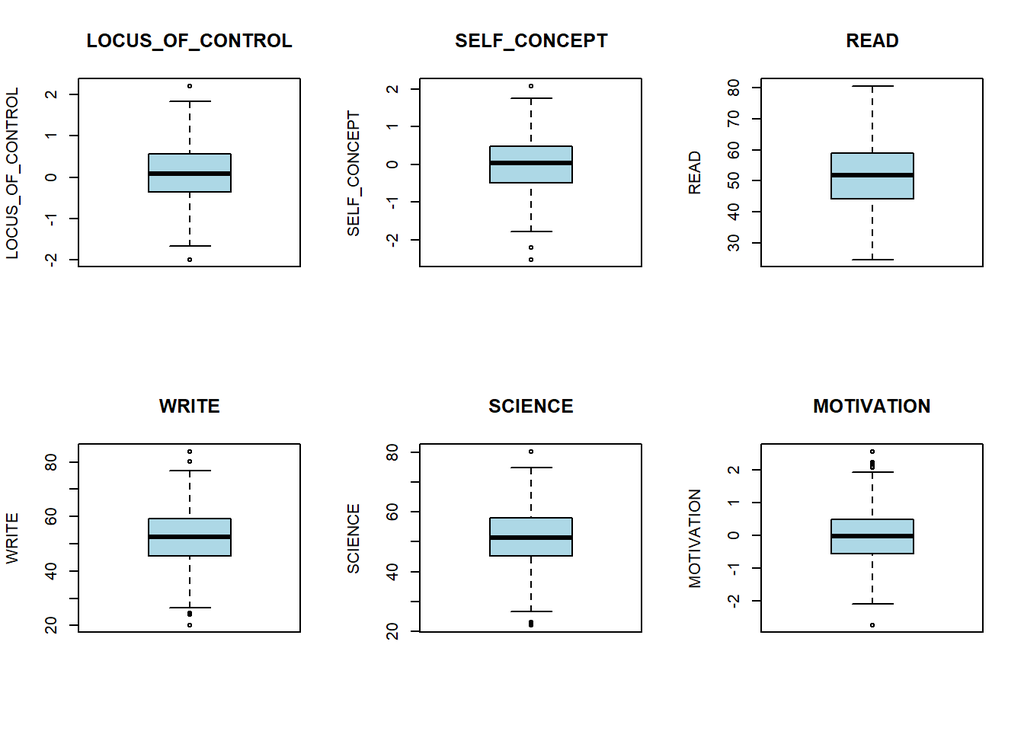

```r
var_num_esame<-c("LOCUS_OF_CONTROL","SELF_CONCEPT","READ","WRITE","SCIENCE","MOTIVATION")
par(mfrow=c(2,3))
for( i in var_num_esame){ boxplot(esame[,i], main=i,
col="lightblue", ylab=i)}
```

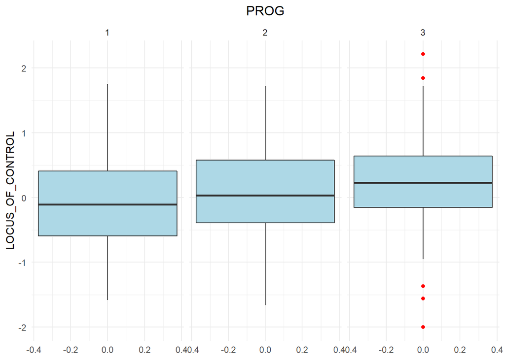

```r
ggplot(esame, aes(y = LOCUS_OF_CONTROL)) +
geom_boxplot(fill = "lightblue", outlier.colour = "red") +
facet_wrap(~PROG) +
ggtitle("PROG") +
theme_minimal() +
theme(plot.title = element_text(hjust =0.5))
```

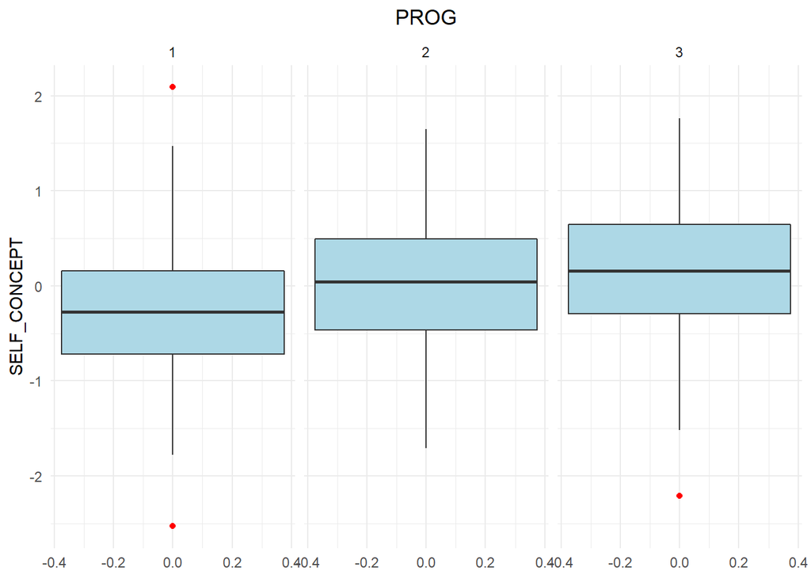

```r
ggplot(esame, aes(y = SELF_CONCEPT)) +
geom_boxplot(fill = "lightblue", outlier.colour = "red") +
facet_wrap(~PROG) +
ggtitle("PROG") +
theme_minimal() +
theme(plot.title = element_text(hjust =0.5))
```

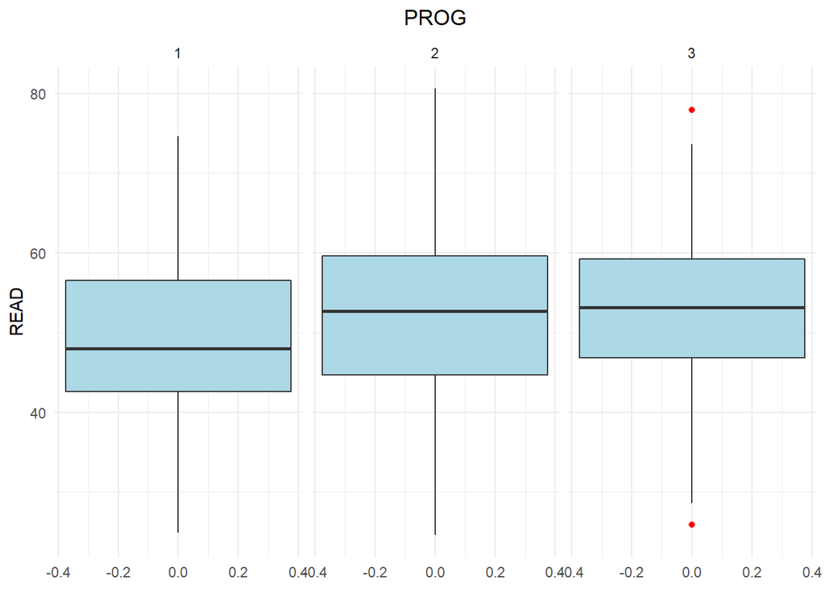

```r
ggplot(esame, aes(y = READ)) +
geom_boxplot(fill = "lightblue", outlier.colour = "red") +
facet_wrap(~PROG) +
ggtitle("PROG") +
theme_minimal() +
theme(plot.title = element_text(hjust =0.5))
```

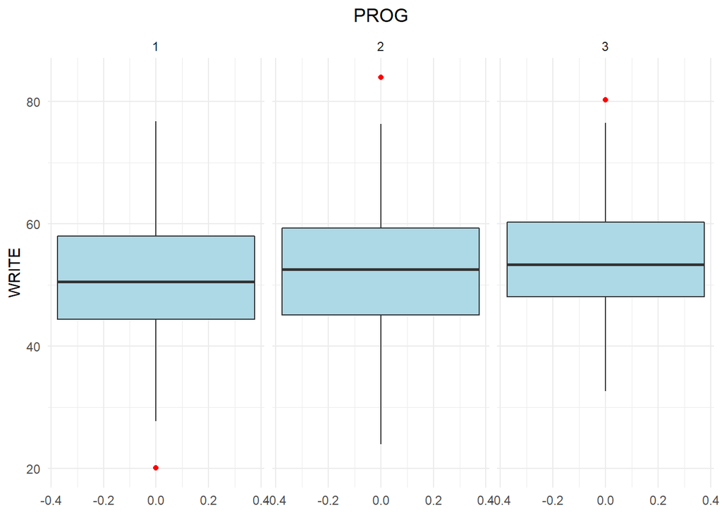

```r
ggplot(esame, aes(y = WRITE)) +
geom_boxplot(fill = "lightblue", outlier.colour = "red") +
facet_wrap(~PROG) +
ggtitle("PROG") +
theme_minimal() +
theme(plot.title = element_text(hjust =0.5))
```

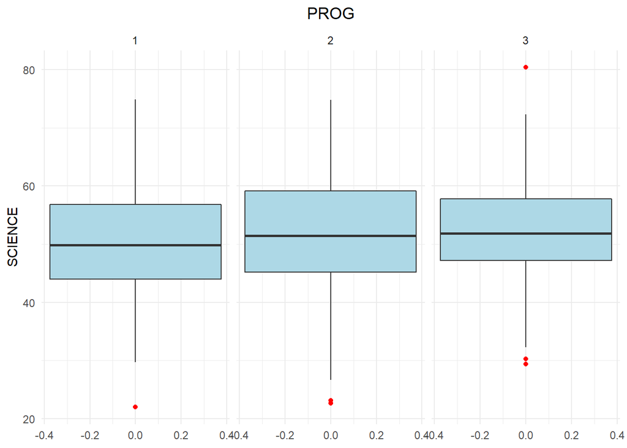

```r
ggplot(esame, aes(y = SCIENCE)) +
geom_boxplot(fill = "lightblue", outlier.colour = "red") +
facet_wrap(~PROG) +
ggtitle("PROG") +
theme_minimal() +
theme(plot.title = element_text(hjust =0.5))
```

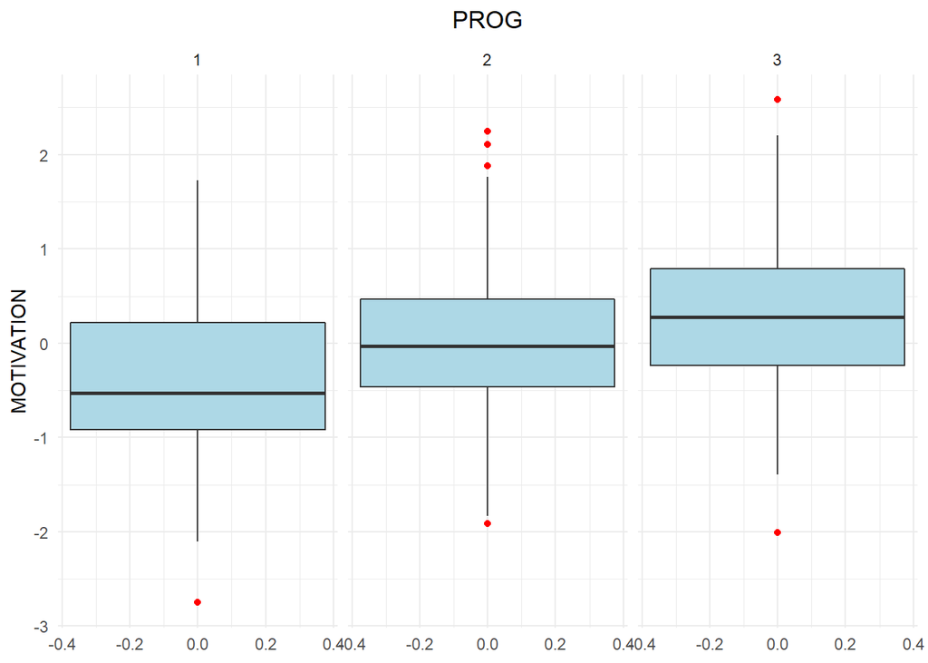

```r
ggplot(esame, aes(y = MOTIVATION)) +
geom_boxplot(fill = "lightblue", outlier.colour = "red") +
facet_wrap(~PROG) +
ggtitle("PROG") +
theme_minimal() +
theme(plot.title = element_text(hjust =0.5))
```

Andiamo a plottare gli istogrammi per ogni variabile esplicativa

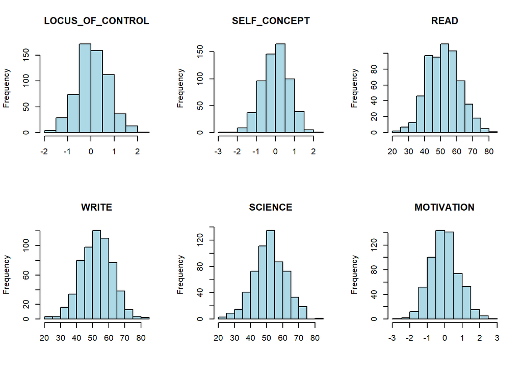

```r
par(mfrow=c(2,3))
for( i in var_num_esame){ hist(esame[,i], main=i,
col="lightblue",xlab=' ')}
```

Descriviamo le correlazioni tra le variabili numeriche

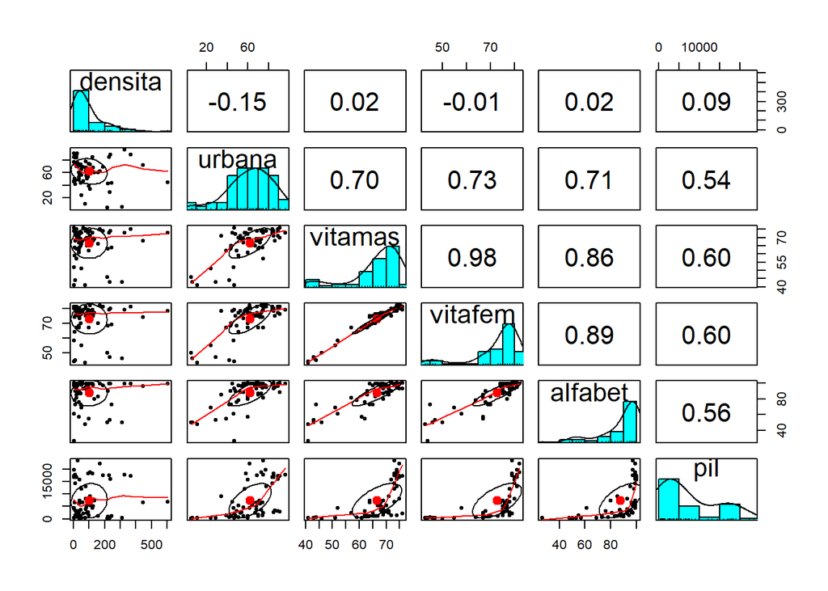

```r
pairs.panels(nazioni[,var_num_nazioni])
```

Vediamo una forte correlazione tra le variabili vitamas e vitafem e anche tre vitafem e alfabet e tra vitamas alfabet vi sono correlazioni meno forti, ma evidenti Le variabili non sembrano distribuirsi normalmente, in particolare, la variabile densità è caratterizzata da una distribuzione assimmetrica positiva, vitamas, vitafem e alfabet sono caratterizzate da una distribuzione assimmetrica negativa, mentre pil sembra presentare due mode (quindi c’è un grande gruppo di paesi poveri e un grande numero di paesi più ricchi)

Andiamo a vedere come fare sia i summary che i pairs panels condizionati

```r
summary(hsb[hsb$gender=='female',var_num_hsb])
```

```
##       read           write            math          science         socst
##  Min.   :28.00   Min.   :35.00   Min.   :33.00   Min.   :29.0   Min.   :26.00
##  1st Qu.:44.00   1st Qu.:50.00   1st Qu.:45.00   1st Qu.:44.0   1st Qu.:46.00
##  Median :50.00   Median :57.00   Median :53.00   Median :50.0   Median :56.00
##  Mean   :51.73   Mean   :54.99   Mean   :52.39   Mean   :50.7   Mean   :52.92
##  3rd Qu.:57.00   3rd Qu.:62.00   3rd Qu.:58.00   3rd Qu.:58.0   3rd Qu.:61.00
##  Max.   :76.00   Max.   :67.00   Max.   :72.00   Max.   :69.0   Max.   :71.00
```

```r
summary(hsb[hsb$gender=='male',var_num_hsb])
```

```
##       read           write            math          science
##  Min.   :31.00   Min.   :31.00   Min.   :35.00   Min.   :26.00
##  1st Qu.:44.50   1st Qu.:41.00   1st Qu.:45.00   1st Qu.:46.00
##  Median :52.00   Median :52.00   Median :52.00   Median :55.00
##  Mean   :52.82   Mean   :50.12   Mean   :52.95   Mean   :53.23
##  3rd Qu.:63.00   3rd Qu.:59.00   3rd Qu.:59.50   3rd Qu.:61.00
##  Max.   :76.00   Max.   :67.00   Max.   :75.00   Max.   :74.00
##      socst
##  Min.   :26.00
##  1st Qu.:46.00
##  Median :51.00
##  Mean   :51.79
##  3rd Qu.:61.00
##  Max.   :71.00
```

Vediamo che per esempio nella lettura i maschi ottengono un punteggio medio più alto

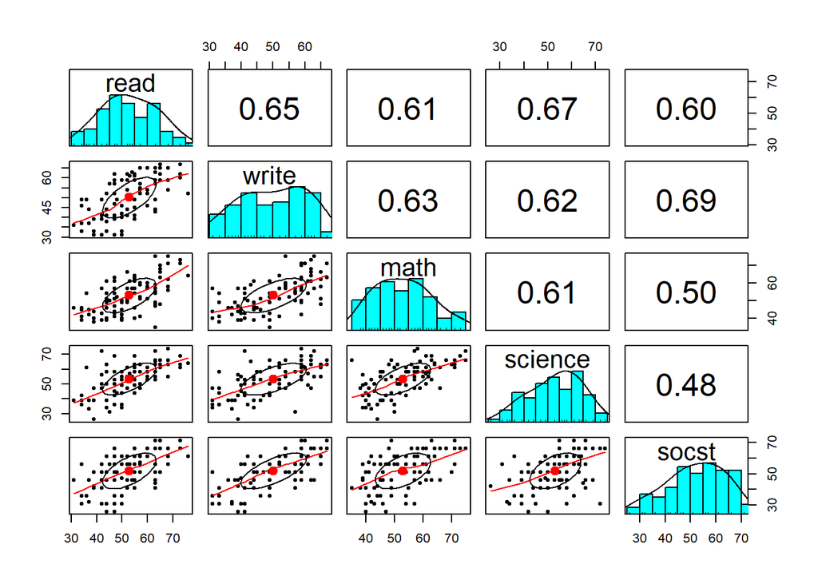

```r
par(mfrow=c(1,2))
pairs.panels(hsb[hsb$gender=='male',var_num_hsb])
```

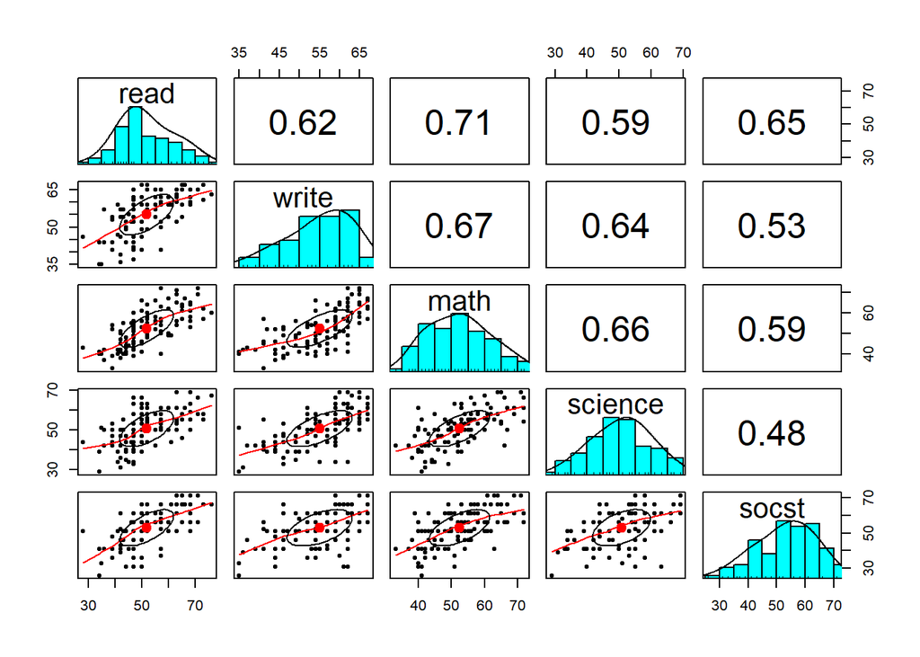

```r
pairs.panels(hsb[hsb$gender=='female',var_num_hsb])
```

## Statistiche descrittive per serie temporali In hartangel che era una serie temporale quando indaghiamo le correlazioni dobbiamo togliere la variabile years

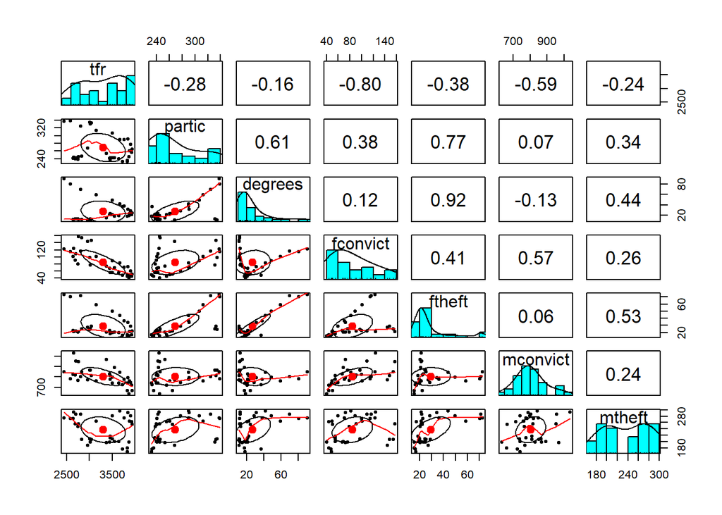

```r
pairs.panels(hartangel[,-1])
```

Andiamo a vedere l’andamento della nostra variabile dipendente nel tempo

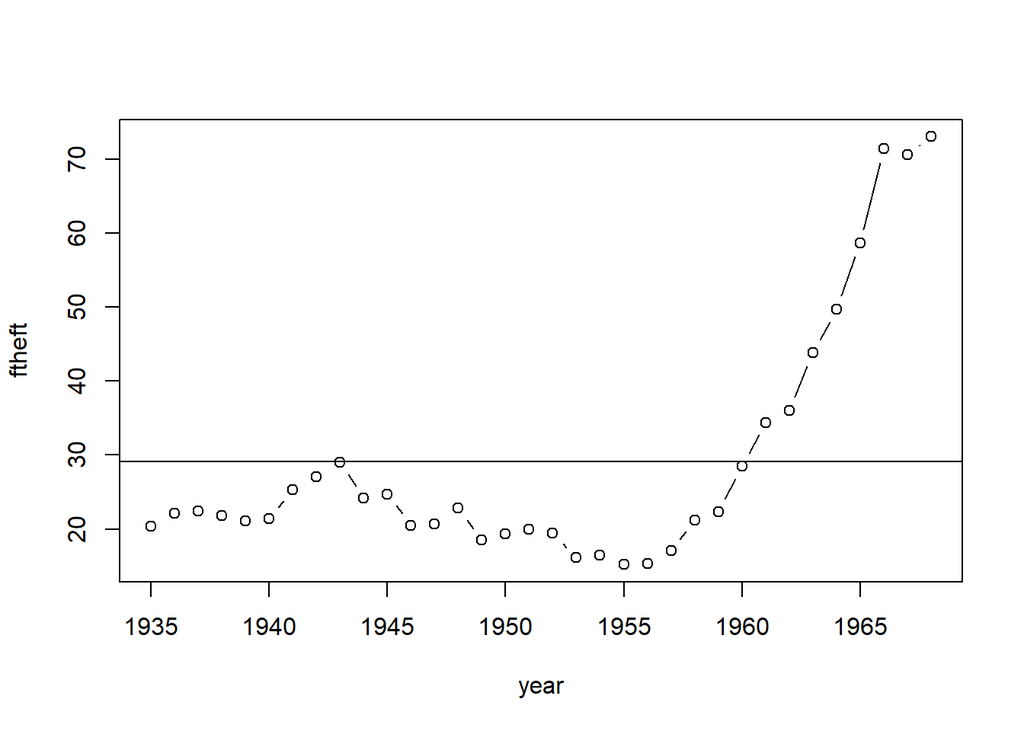

```r
plot(hartangel$year,hartangel$ftheft,ylab="ftheft",xlab='year',type='b')
abline(h=mean(hartangel$ftheft))
```

Vediamo che dal 1955 in poi inizia un trend crescente, mentre prima del ’55 si vedono fluttuazioni intorno al valore 20, inoltre in questo range di fluttuazioni si vedono valori che tendono ad essere uguali tra di loro che indicano la possibile presenza di autocorrelazione positiva.

ATTENZIONE QUESTA NON E’ L’AUTOCORRELAZIONE DEI RESIDUIIII Andiamo a verificare la presenza di una correlazione positiva attraverso un correlogramma

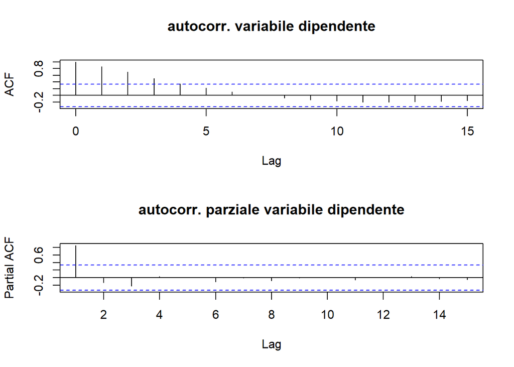

```r
par(mfrow=c(2,1))
acf(hartangel$ftheft,main='autocorr. variabile dipendente')
pacf(hartangel$ftheft,main='autocorr. parziale variabile dipendente')
```

### Modelli lineari classici multipli: diagnostica ipotesi e correlazione tra i residui

## Soluzione eteroschedasticità apportando trasformazioni alle variabili dipendenti ed indipendenti

Iniziamo svolgendo una regressione lineare tra le variabili dipendenti e indipendenti richieste (alt+126= ~)

```r
lin_nazioni<-lm(pil~alfabet, nazioni)
summary(lin_nazioni) ## vediamo che il model
```

```
##
## Call:
## lm(formula = pil ~ alfabet, data = nazioni)
##
## Residuals:
##    Min     1Q Median     3Q    Max
##  -7461  -4800  -2668   5282  13912
##
## Coefficients:
##             Estimate Std. Error t value Pr(>|t|)
## (Intercept) -13689.5     3919.6  -3.493 0.000873 ***
## alfabet        239.7       44.0   5.448 8.69e-07 ***
## ---
## Signif. codes:  0 '***' 0.001 '**' 0.01 '*' 0.05 '.' 0.1 ' ' 1
##
## Residual standard error: 5826 on 64 degrees of freedom
## Multiple R-squared:  0.3168, Adjusted R-squared:  0.3061
## F-statistic: 29.68 on 1 and 64 DF,  p-value: 8.686e-07
```

Andiamo a verificare la presenza di eteroschedasticità

```r
white.test(lin_nazioni)
```

```
##   Test.Statistic            P
## 1       13.82682 0.0009943592
```

```r
white_lm(lin_nazioni)
```

```
## # A tibble: 1 x 5
##   statistic  p.value parameter method       alternative
##       <dbl>    <dbl>     <dbl> <chr>        <chr>
## 1      13.8 0.000994         2 White's Test greater
```

Vediamo che il test di white segnala la presenza di eteroschedasticità dei residui Verifichiamo la presenza di eteroschedasticità anche in maniera grafica

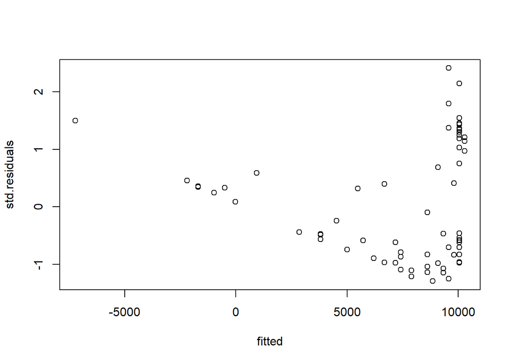

```r
plot(lin_nazioni$fitted.values, rstandard(lin_nazioni), xlab='fitted',ylab='std.residuals')
```

Notiamo che i residui hanno un andamento a ventaglio, quindi si può desumere anche graficamente di essere in presenza di eteroschedasticità.

Vediamo ora alcune trasformazioni applicate alle variabili dipendenti e indipendenti e come esse agiscono sulla bontà di adattamento del modello, sulla significatività delle variabili esplicative e sull’eteroschedasticità dei residui:

- trasformazione lin-log

```r
linlog_nazioni<-lm(pil~I(log(alfabet)), nazioni)
summary(linlog_nazioni)
```

```
##
## Call:
## lm(formula = pil ~ I(log(alfabet)), data = nazioni)
##
## Residuals:
##    Min     1Q Median     3Q    Max
##  -7303  -4929  -2475   5953  14331
##
## Coefficients:
##                 Estimate Std. Error t value Pr(>|t|)
## (Intercept)       -57490      13869  -4.145 0.000102 ***
## I(log(alfabet))    14566       3113   4.679 1.54e-05 ***
## ---
## Signif. codes:  0 '***' 0.001 '**' 0.01 '*' 0.05 '.' 0.1 ' ' 1
##
## Residual standard error: 6084 on 64 degrees of freedom
## Multiple R-squared:  0.2549, Adjusted R-squared:  0.2432
## F-statistic: 21.89 on 1 and 64 DF,  p-value: 1.543e-05
```

Il coefficente 14566 va interpretato come un incremento del 1% del tasso di alfabetizzazione porta ad un incremento di 145 dollari del PIL (quandoo abbiamo solo il log nella var ind dividiamo per 100) vediamo che il modello è ancora significativo, ma abbiamo perso di R^2 quindi possiamo dire che questo modello interpreta peggio i dati rispetto a quello lineare

Andiamo di nuvo a controllare la presenza di eteroschedasticità dei residui:

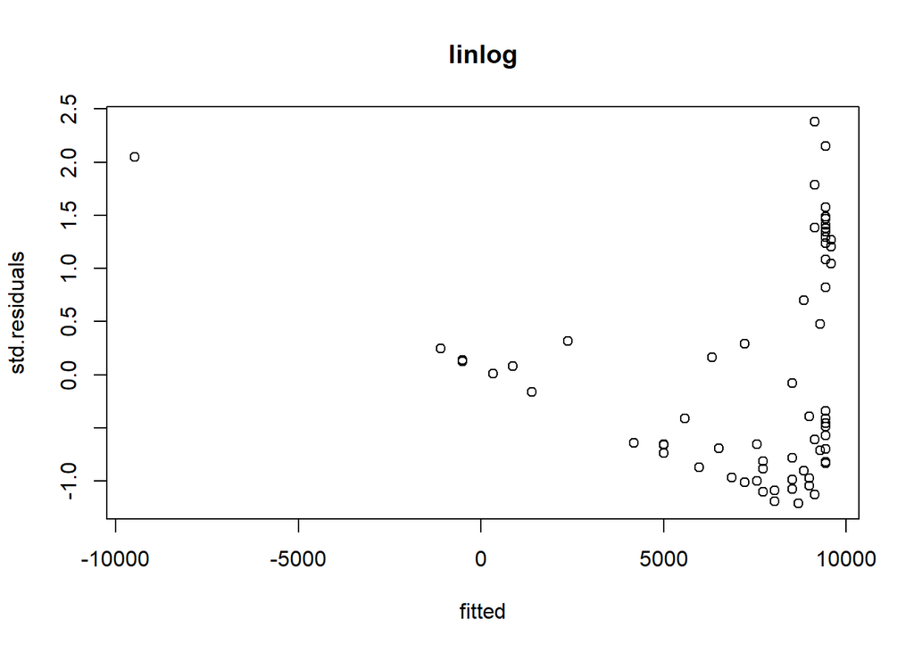

```r
plot(linlog_nazioni$fitted.values, rstandard(linlog_nazioni), xlab='fitted',ylab='std.residuals', main="linlog")
```

```r
white_lm(linlog_nazioni)
```

```
## # A tibble: 1 x 5
##   statistic  p.value parameter method       alternative
##       <dbl>    <dbl>     <dbl> <chr>        <chr>
## 1      14.6 0.000670         2 White's Test greater
```

Vediamo che i residui si dispongono a ventaglio, quindi graficamente notiamo la presenza di eteroschedasticità. Che viene anche confermata dal White Test

- Trasformazioni loglog

```r
loglog_nazioni<-lm((log(pil))~I(log(alfabet)), nazioni)
summary(loglog_nazioni)
```

```
##
## Call:
## lm(formula = (log(pil)) ~ I(log(alfabet)), data = nazioni)
##
## Residuals:
##     Min      1Q  Median      3Q     Max
## -1.6880 -0.6551 -0.1290  0.8736  2.3993
##
## Coefficients:
##                 Estimate Std. Error t value Pr(>|t|)
## (Intercept)      -9.2166     2.0702  -4.452 3.48e-05 ***
## I(log(alfabet))   3.9268     0.4647   8.450 5.20e-12 ***
## ---
## Signif. codes:  0 '***' 0.001 '**' 0.01 '*' 0.05 '.' 0.1 ' ' 1
##
## Residual standard error: 0.9081 on 64 degrees of freedom
## Multiple R-squared:  0.5273, Adjusted R-squared:   0.52
## F-statistic: 71.41 on 1 and 64 DF,  p-value: 5.196e-12
```

Vediamo come la variabile alfabet rimane significativa e la capacità del modello di adattarsi ai dati migliora di molto R^2=0.5 Il coefficente adesso si interpreta come elasticità, ovvero un rapporto tra variazioni percentuali (ovvero l’aumento del 1% del tasso di alfabetizzazione è associato ad un aumento del 3.9% del pilprocapite)

Andiamo a valutare la presenza di eteroschedasticità:

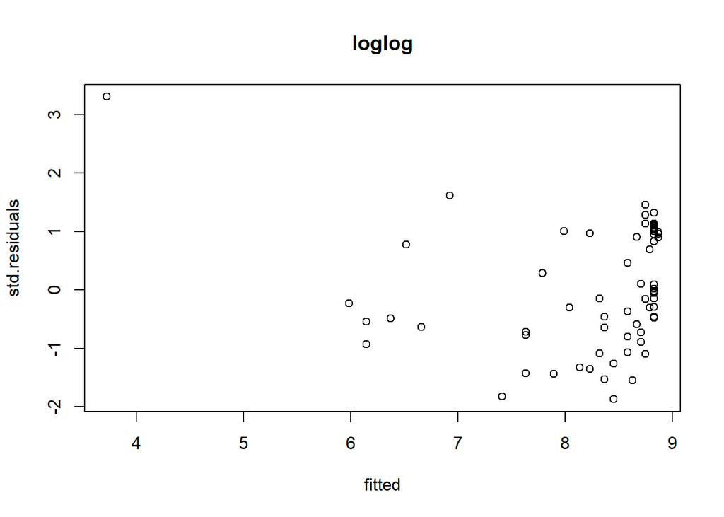

```r
plot(loglog_nazioni$fitted.values, rstandard(loglog_nazioni), xlab='fitted',ylab='std.residuals', main="loglog")
```

```r
white_lm(loglog_nazioni)
```

```
## # A tibble: 1 x 5
##   statistic   p.value parameter method       alternative
##       <dbl>     <dbl>     <dbl> <chr>        <chr>
## 1      22.5 0.0000128         2 White's Test greater
```

Da questo grafico si vede un grande miglioramento dei residui, ma non posso dire nulla sull’eteroschedasticità, mentre il test di white è ancora significativo e quindi gli errori secondo il test sono ancora eteroschedastici.

- trasformazioni loglin

```r
loglin_nazioni<-lm((log(pil))~alfabet, nazioni)
summary(loglin_nazioni)
```

```
##
## Call:
## lm(formula = (log(pil)) ~ alfabet, data = nazioni)
##
## Residuals:
##     Min      1Q  Median      3Q     Max
## -1.6371 -0.5733 -0.1513  0.7705  1.7647
##
## Coefficients:
##             Estimate Std. Error t value Pr(>|t|)
## (Intercept) 2.802183   0.556619   5.034 4.16e-06 ***
## alfabet     0.062221   0.006249   9.958 1.25e-14 ***
## ---
## Signif. codes:  0 '***' 0.001 '**' 0.01 '*' 0.05 '.' 0.1 ' ' 1
##
## Residual standard error: 0.8273 on 64 degrees of freedom
## Multiple R-squared:  0.6077, Adjusted R-squared:  0.6016
## F-statistic: 99.16 on 1 and 64 DF,  p-value: 1.246e-14
```

Andiamo a verificare se vi è ancora o meno la presenza di eteroschedasticità

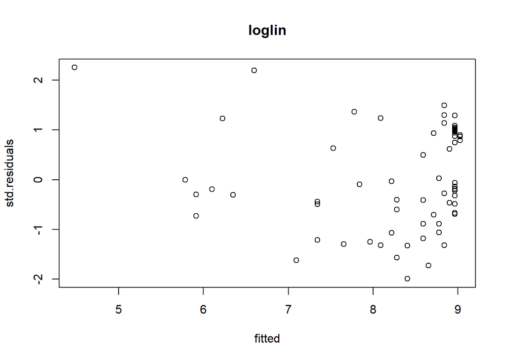

```r
plot(loglin_nazioni$fitted.values, rstandard(loglin_nazioni), xlab='fitted',ylab='std.residuals', main="loglin")
```

```r
white_lm(loglin_nazioni)
```

```
## # A tibble: 1 x 5
##   statistic p.value parameter method       alternative
##       <dbl>   <dbl>     <dbl> <chr>        <chr>
## 1      3.62   0.163         2 White's Test greater
```

Graficamente vediamo che l’andamento dei residui sembra migliorato, in quanto sembrano essere più omoschedastici però non si capisce molto bene, notiamo che il p-value è alto e ciò porta all’accettazione dell’ipotesi nulla di omoschedasticità. Quindi per bontà di adattamento e per avere riportato gli errori ad essere omoschedastici questo modello sembra essere il migliore.

- trasformazioni polinomiali (in questo caso di secondo grado)

```r
quad1_nazioni<-lm(pil~alfabet+I(alfabet^2), nazioni)
summary(quad1_nazioni)
```

```
##
## Call:
## lm(formula = pil ~ alfabet + I(alfabet^2), data = nazioni)
##
## Residuals:
##    Min     1Q Median     3Q    Max
##  -7875  -4754    197   4711  13259
##
## Coefficients:
##               Estimate Std. Error t value Pr(>|t|)
## (Intercept)  24473.855  11053.547   2.214 0.030447 *
## alfabet       -891.719    312.555  -2.853 0.005852 **
## I(alfabet^2)     7.678      2.103   3.650 0.000534 ***
## ---
## Signif. codes:  0 '***' 0.001 '**' 0.01 '*' 0.05 '.' 0.1 ' ' 1
##
## Residual standard error: 5335 on 63 degrees of freedom
## Multiple R-squared:  0.4361, Adjusted R-squared:  0.4182
## F-statistic: 24.36 on 2 and 63 DF,  p-value: 1.456e-08
```

Vediamo che l’andamento quadratico di secondo grado è significativo in quanto sono significativi sia i due coefficenti, sia il test F Gli standard error così elevati dicono che potrebbe essere stata introdotta multicollinearità tra le variabili indipendenti In questo caso però potremmo avere introdotto multicollinearità tra le variabili esplicative, andiamo quindi a controllare

```r
vif(quad1_nazioni)
```

```
##      alfabet I(alfabet^2)
##     60.17541     60.17541
```

Infatti il Vif di entrambe le variabili esplicative risulta essere molto maggiore di 10, questo stabilisce la presenza di multicollinearità tra le due variabili

Per eliminare la multicollinearità possiamo centrare le variabili indipendenti: - procediamo in un primo momento a creare la variabile centrata, che non è altro che la variabile meno la sua media

```r
nazioni$alfabet_centrata<-nazioni$alfabet-mean(nazioni$alfabet)
```

- Andiamo a rifare la regressioni usando la variabile centrata ed il suo quadrato

```r
quad2_nazioni<-lm(pil~alfabet_centrata+I(alfabet_centrata^2), nazioni)
summary(quad2_nazioni)
```

```
##
## Call:
## lm(formula = pil ~ alfabet_centrata + I(alfabet_centrata^2),
##     data = nazioni)
##
## Residuals:
##    Min     1Q Median     3Q    Max
##  -7875  -4754    197   4711  13259
##
## Coefficients:
##                       Estimate Std. Error t value Pr(>|t|)
## (Intercept)           5263.832    862.127   6.106 7.01e-08 ***
## alfabet_centrata       453.013     70.978   6.382 2.35e-08 ***
## I(alfabet_centrata^2)    7.678      2.103   3.650 0.000534 ***
## ---
## Signif. codes:  0 '***' 0.001 '**' 0.01 '*' 0.05 '.' 0.1 ' ' 1
##
## Residual standard error: 5335 on 63 degrees of freedom
## Multiple R-squared:  0.4361, Adjusted R-squared:  0.4182
## F-statistic: 24.36 on 2 and 63 DF,  p-value: 1.456e-08
```

Notiamo che abbiamo dei t-value molto più ampi, in quanto nel caso di multicollinearità gli standard error erano molto alti rispetto al loro valore reale

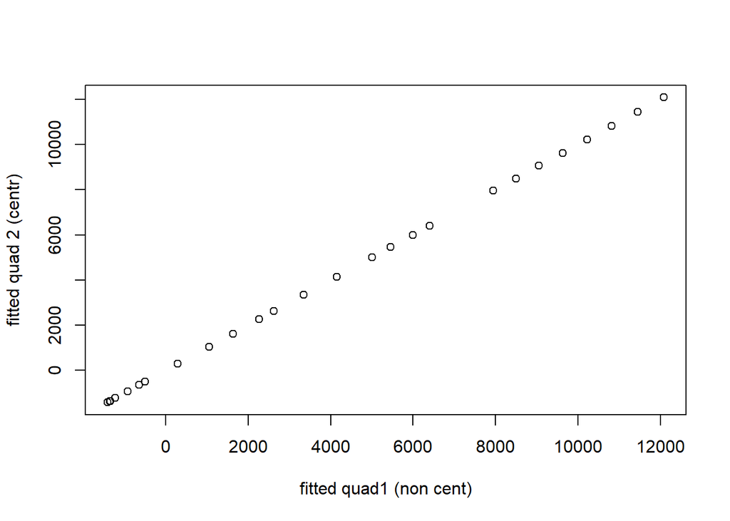

```r
plot(quad1_nazioni$fitted.values, quad2_nazioni$fitted.values, xlab='fitted quad1 (non cent)', ylab='fitted quad 2 (centr)')
```

Vediamo che i valori fittati sono pressochè identici

Andiamo a testare l’eteroschedasticità, in questo caso dato che abbiamo più di una variabile dipendente dobbiamo aggiungere le interazuibu all’interno del white test

```r
white_lm(quad2_nazioni, interaction=T)
```

```
## # A tibble: 1 x 5
##   statistic p.value parameter method       alternative
##       <dbl>   <dbl>     <dbl> <chr>        <chr>
## 1      16.0 0.00697         5 White's Test greater
```

Vediamo che anche in questo caso gli errori sono eteroschedastici.

## Verifica della presenza di multicollinearità

Verificare la presenza di multicollinearità tra le variabili esplicative è una delle prime cose che deve essere fatta quando vogliamo fare una regressione che abbia più di una variabile esplicativa

```r
mod1_nazioni<-lm(pil~densita+urbana+vitafem+vitamas+alfabet+relig, nazioni)
summary(mod1_nazioni)
```

```
##
## Call:
## lm(formula = pil ~ densita + urbana + vitafem + vitamas + alfabet +
##     relig, data = nazioni)
##
## Residuals:
##     Min      1Q  Median      3Q     Max
## -8367.9 -4094.3  -328.8  3226.2 12376.3
##
## Coefficients:
##               Estimate Std. Error t value Pr(>|t|)
## (Intercept) -22033.709   5251.591  -4.196 9.45e-05 ***
## densita          5.148      5.838   0.882  0.38153
## urbana          32.363     50.847   0.636  0.52697
## vitafem        265.059    411.114   0.645  0.52164
## vitamas         70.108    408.057   0.172  0.86419
## alfabet         21.886     91.730   0.239  0.81226
## relig2       -2461.099   2170.794  -1.134  0.26157
## relig3        4821.352   1609.681   2.995  0.00403 **
## ---
## Signif. codes:  0 '***' 0.001 '**' 0.01 '*' 0.05 '.' 0.1 ' ' 1
##
## Residual standard error: 5168 on 58 degrees of freedom
## Multiple R-squared:  0.5127, Adjusted R-squared:  0.4539
## F-statistic: 8.718 on 7 and 58 DF,  p-value: 2.839e-07
```

Vediamo che il modello ha un test F significativo, ovvero esiste almeno un coefficiente che è diverso da 0,in questo caso l’unica variabile significativa è la relig3 ovvero la presenza della religione protestante

Testiamo la presenza di multicollinearità

-Matrice di correlazione anche tramite il comando pairs.panels come visto nella statistica descrittiva

- VIF(Varianza multifattoriale)

```r
ols_vif_tol(mod1_nazioni)
```

```
##   Variables  Tolerance       VIF
## 1   densita 0.90762091  1.101782
## 2    urbana 0.38357395  2.607059
## 3   vitafem 0.02355899 42.446641
## 4   vitamas 0.02904083 34.434274
## 5   alfabet 0.18109586  5.521937
## 6    relig2 0.80631027  1.240217
## 7    relig3 0.81683246  1.224241
```

```r
vif(mod1_nazioni)
```

```
##              GVIF Df GVIF^(1/(2*Df))
## densita  1.101782  1        1.049658
## urbana   2.607059  1        1.614639
## vitafem 42.446641  1        6.515109
## vitamas 34.434274  1        5.868072
## alfabet  5.521937  1        2.349880
## relig    1.364066  2        1.080709
```

Considerando la soglia 10 vediamo un problema di multicollinearità per la variabili vitafem e vitamas, in quanto molto probabilmente l’aspettativa di vita delle femmine e dei maschi dipende dagli stessi fattori, quindi se ne deve inserire solo una delle due variabili esplicative

- Condition index

```r
ols_eigen_cindex(mod1_nazioni)
```

```
##     Eigenvalue Condition Index    intercept     densita       urbana
## 1 5.8435403371        1.000000 4.146107e-04 0.007592516 1.010306e-03
## 2 1.0089347275        2.406614 3.158112e-06 0.007629420 2.211371e-06
## 3 0.5998283855        3.121221 8.239702e-05 0.353333515 3.465049e-04
## 4 0.4865830514        3.465449 8.788833e-04 0.504208618 3.569386e-03
## 5 0.0459604379       11.275763 9.605069e-02 0.090457517 5.179907e-01
## 6 0.0113479022       22.692390 5.388246e-01 0.019160893 4.330651e-01
## 7 0.0035538597       40.549722 3.487615e-01 0.001104670 1.145356e-02
## 8 0.0002512986      152.490574 1.498409e-02 0.016512851 3.256222e-02
##        vitafem      vitamas      alfabet       relig2      relig3
## 1 1.274152e-05 1.543974e-05 1.741487e-04 0.0031184172 0.006063044
## 2 2.262155e-07 1.443358e-07 6.405641e-06 0.4874862559 0.173563754
## 3 9.647968e-07 1.573052e-06 1.259138e-06 0.1407552812 0.461093602
## 4 3.156164e-05 3.762416e-05 3.111197e-04 0.2331720590 0.239504437
## 5 1.530420e-04 2.453426e-04 6.369822e-09 0.0003791654 0.055211194
## 6 1.642043e-03 2.080159e-03 1.935465e-01 0.0287327096 0.006094018
## 7 2.328528e-02 4.330982e-02 7.529275e-01 0.0770575063 0.046892873
## 8 9.748741e-01 9.543099e-01 5.303314e-02 0.0292986054 0.011577078
```

Abbiamo ben due autovalori associati ad un condition index con autovalori maggiori di 30, uno dei due spiega pIù del 95% della vairbilità di vitamas e vitafem, quindi alche il condition index indica la presenza di multicollinearità tra queste due variabili e si procede ad omettere una fra vitamas e vitafem, oppure si potrebbe calcolarne la media.

Decidiamo di togliere dal modello vitamas e andiamo di nuovo a testare la presenza di multicollinearità

```r
mod2_nazioni<-lm(pil~densita+urbana+vitafem+alfabet+relig, nazioni)
summary(mod2_nazioni)
```

```
##
## Call:
## lm(formula = pil ~ densita + urbana + vitafem + alfabet + relig,
##     data = nazioni)
##
## Residuals:
##     Min      1Q  Median      3Q     Max
## -8357.1 -4109.6  -374.6  3196.2 12354.8
##
## Coefficients:
##               Estimate Std. Error t value Pr(>|t|)
## (Intercept) -22005.133   5205.608  -4.227 8.34e-05 ***
## densita          5.282      5.739   0.920  0.36115
## urbana          31.374     50.103   0.626  0.53360
## vitafem        330.796    149.148   2.218  0.03042 *
## alfabet         20.868     90.782   0.230  0.81899
## relig2       -2541.140   2102.705  -1.209  0.23167
## relig3        4836.980   1593.836   3.035  0.00358 **
## ---
## Signif. codes:  0 '***' 0.001 '**' 0.01 '*' 0.05 '.' 0.1 ' ' 1
##
## Residual standard error: 5126 on 59 degrees of freedom
## Multiple R-squared:  0.5125, Adjusted R-squared:  0.4629
## F-statistic: 10.34 on 6 and 59 DF,  p-value: 8.403e-08
```

```r
ols_vif_tol(mod2_nazioni)
```

```
##   Variables Tolerance      VIF
## 1   densita 0.9239501 1.082310
## 2    urbana 0.3885518 2.573659
## 3   vitafem 0.1760520 5.680141
## 4   alfabet 0.1818551 5.498882
## 5    relig2 0.8452392 1.183097
## 6    relig3 0.8194492 1.220332
```

```r
ols_eigen_cindex(mod2_nazioni)
```

```
##    Eigenvalue Condition Index    intercept     densita       urbana
## 1 4.868516568        1.000000 5.922456e-04 0.011466635 1.464889e-03
## 2 1.008607534        2.197036 4.728968e-06 0.007217311 7.144921e-07
## 3 0.598738281        2.851542 8.847540e-05 0.394498541 3.437302e-04
## 4 0.466282786        3.231273 1.490959e-03 0.470182240 5.523430e-03
## 5 0.044805166       10.423997 1.186160e-01 0.093336018 4.970642e-01
## 6 0.010806096       21.225792 4.398915e-01 0.022271511 4.437282e-01
## 7 0.002243569       46.583120 4.393161e-01 0.001027744 5.187486e-02
##        vitafem      alfabet       relig2      relig3
## 1 1.357979e-04 2.499443e-04 4.864762e-03 0.009207055
## 2 2.216398e-06 7.865957e-06 5.154375e-01 0.171221687
## 3 7.852879e-06 1.944954e-06 1.324095e-01 0.437789146
## 4 3.844941e-04 5.427798e-04 2.559910e-01 0.271025070
## 5 1.860275e-03 1.533274e-04 8.343093e-05 0.049003446
## 6 1.742514e-02 2.755957e-01 4.395841e-02 0.003406401
## 7 9.801842e-01 7.234484e-01 4.725535e-02 0.058347194
```

Generalmente dopo aver risolto il problema di multicollinearità nel modello si va ad indagare se vi è eteroschedasticità o meno.

## Studio della normalità dei residui

Costruiamo la nostra regressione

```r
m1_countries<-lm(Life.expectancy~ ISPs.million+ Irrigated+ Under.14 +Literacy.Rate,countries)
summary(m1_countries)
```

```
##
## Call:
## lm(formula = Life.expectancy ~ ISPs.million + Irrigated + Under.14 +
##     Literacy.Rate, data = countries)
##
## Residuals:
##      Min       1Q   Median       3Q      Max
## -21.3828  -3.3426   0.5599   4.3173  17.5504
##
## Coefficients:
##                 Estimate Std. Error t value Pr(>|t|)
## (Intercept)    9.261e+01  1.462e+01   6.333 3.63e-07 ***
## ISPs.million  -3.255e-02  1.861e-01  -0.175    0.862
## Irrigated      6.513e-06  1.493e-05   0.436    0.665
## Under.14      -9.566e-01  2.081e-01  -4.598 6.01e-05 ***
## Literacy.Rate  3.402e-02  1.125e-01   0.302    0.764
## ---
## Signif. codes:  0 '***' 0.001 '**' 0.01 '*' 0.05 '.' 0.1 ' ' 1
##
## Residual standard error: 7.867 on 33 degrees of freedom
## Multiple R-squared:  0.657,  Adjusted R-squared:  0.6155
## F-statistic:  15.8 on 4 and 33 DF,  p-value: 2.542e-07
```

La normalità dei residui viene in un primo luogo indagata graficamente, attraverso l’uso di un QQ-plot e anche dell’istogramma dei residui

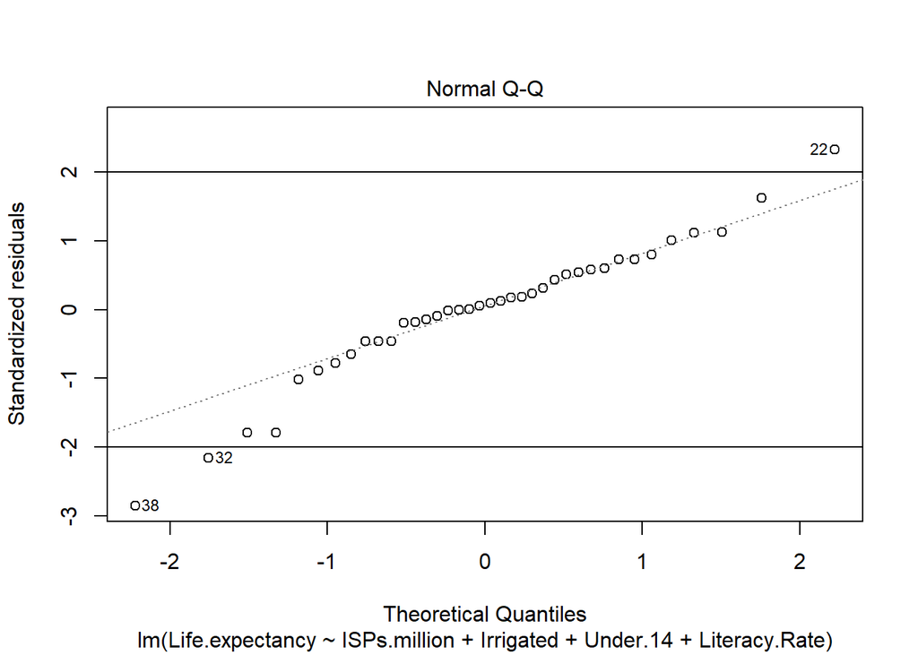

```r
plot(m1_countries, which=2) # il prof consiglia di approfondire il which
abline(h=-2)
abline(h=2)
```

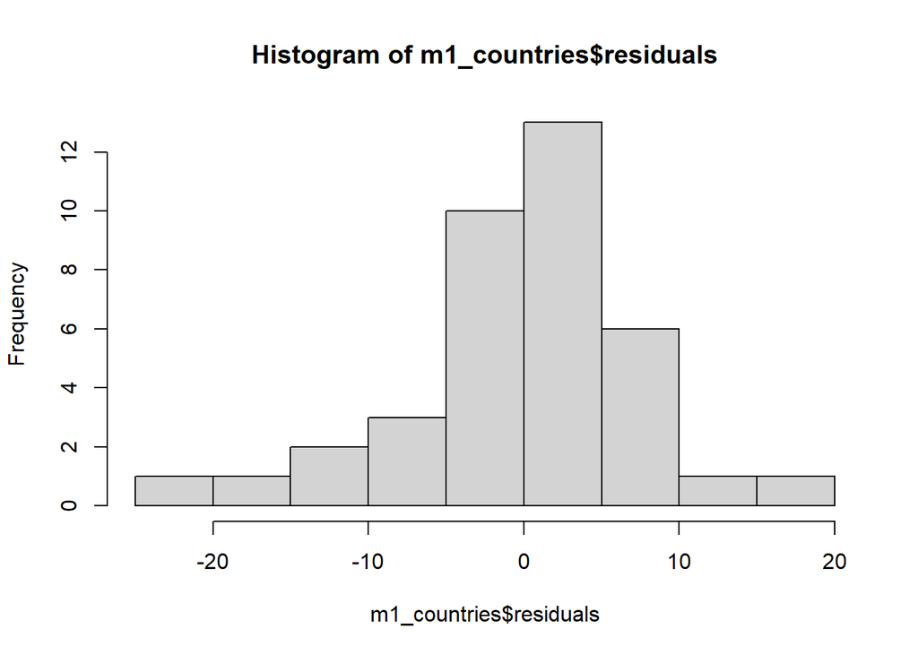

```r
hist(m1_countries$residuals)
```

Vediamo in questo caso che vi sono valori che si discostano dalla normalità (probabilmente sono degli outlier), anche se gli errori sembrano approssimativamente distribuirsi in modo normale

Andiamo a verificare la normalità tramite l’uso di alcuni test:

```r
ols_test_normality(m1_countries)
```

```
## -----------------------------------------------
##        Test             Statistic       pvalue
## -----------------------------------------------
## Shapiro-Wilk              0.9488         0.0811
## Kolmogorov-Smirnov        0.1373         0.4322
## Cramer-von Mises          2.6918         0.0000
## Anderson-Darling          0.7831         0.0384
## -----------------------------------------------
```

I primi due test ci segnalano la presenza di normalità infatti accettano l’ipotesi nulla( N.B:il test di shapiro-wilk è molto sensibile a gli outliers)

## Studio degli outliers e dei valori influenti

Costruisco gli scalari k e n, pari rispettivamente al numero di variabili + intercetta (utilizzate nel modello su cui voglio indagare gli outliers) e al numero delle osservazioni. Questi saranno utili per andare a costruire le soglie.

```r
k=length(coef(mod2_nazioni))
k
```

```
## [1] 7
```

```r
n=nrow(nazioni)
n
```

```
## [1] 66
```

Vado ora ad indagare graficamente la presenza di outlier a livello grafico:

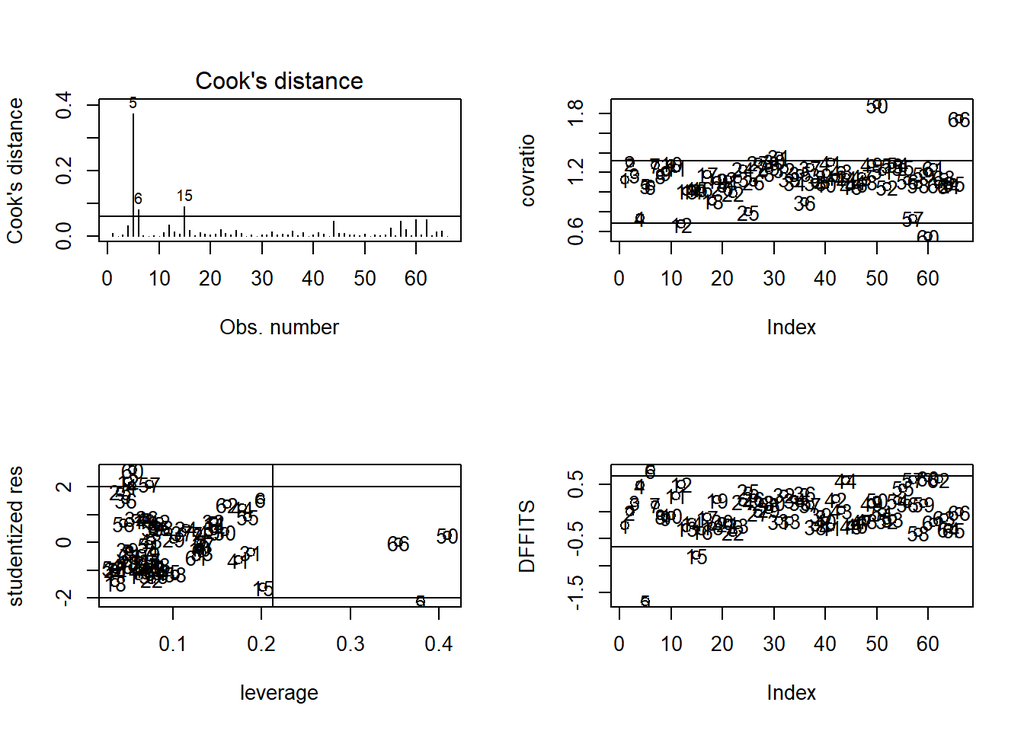

```r
par(mfrow=c(2,2))

# primo grafico: distanza di cook vs indice delle osservazioni
plot(mod2_nazioni,which=4)
abline(h=4/n)

#aggiungiamo ora il secondo plot che è covratio
plot(covratio(mod2_nazioni),ylab='covratio')
abline(h=1+3*k/n)
abline(h=1-3*k/n)
text(covratio(mod2_nazioni))

#aggiungiamo ora il terzo plot studentized resisiduals vs leverage (anche detti hat values)
#aggiungendo anche le soglie che per gli stud residuals sono +2 e -2
#aggiungiamo anche le soglie di leverage che sono 2k/n
plot(hatvalues(mod2_nazioni),rstudent(mod2_nazioni),xlab='leverage',ylab='studentized res')
abline(h=2)
abline(h=-2)
abline(v=2*k/n)
text(hatvalues(mod2_nazioni),rstudent(mod2_nazioni))

#l'ultimo grafico da aggiungere è quello dei dffits che ha soglie 2*sqrt(k/n)
plot(dffits(mod2_nazioni), ylab='DFFITS')
text(dffits(mod2_nazioni))
abline(h=2*sqrt(k/n))
abline(h=-2*sqrt(k/n))
```

Le soglie vengono usate come linee guida, ma la decisione di quali osservazioni effettivamente eliminare viene presa a braccio cercando di sintetizzare le informazioni date dai vari grafici, eliminerò quindi osservazioni che sono troppo ‘fuori’ in un grafico oppure osservazioni che vengono ritenute outliers su più grafici

La cook’s distance è una misura di influenza, ovvero di quanto un’osservazione influisca sulle stime dei parametri, vediamo che l’osservazione 5 ha un valore molto influente, notiamo anche che le osservazioni6 e 15 superano le soglie e bisogna prestare attenzione (anche se non superano le soglie) a le osservazioni 60,62 e anche la 57

Il covratio è un’altra misura di influenza, notiamo osservazioni fuori dalle soglie come la 50, la 66 e la 60 (che era già stata notata precedentemente)

I residui studentizzati ennesima misura di influenza, indica che la 66, la 50 (entrambe già evidenziate dal covratio) e la 5 (già evidenziata dalla distanza di coook sono osservazioni influenti)

Il DFFITS ci segnala soprattuto l’osservazione 5 che è molto fuori

La decisione di escludere valori viene fatta escludendo inanzitutto gli outlier e poi fare a braccio e trovare quali osservazioni influenti escludere.

Ora uso dbetas, la quale è una misura di influenza della singola osservazione sul singolo coefficente, ovvero escludo l’intercetta (di cui non si può fare a meno nel modello, o se si decide di escluderla bisogna comunque essere cauti) per andare a vedere quali outliers vi sono per ogni variabili indipendente

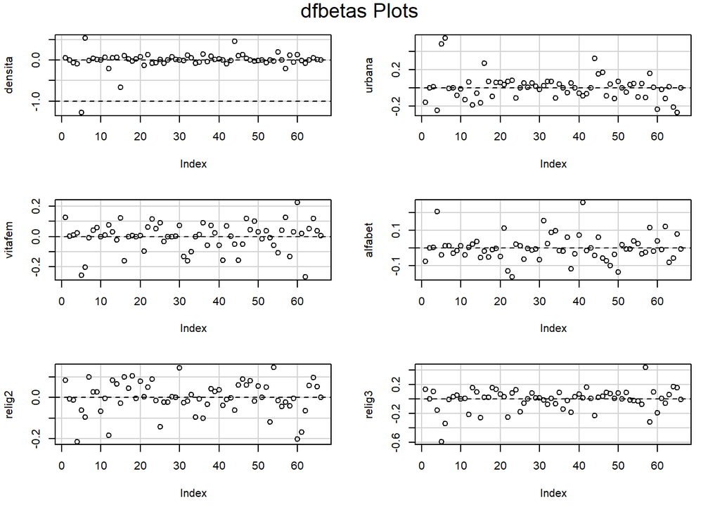

```r
dfbetasPlots(mod2_nazioni)
```

dfbetasPlots(mod2) #commenti al minuto 56 Vediamo come l’osservazione 5 e 60 compaiono spesso,quindi anche i dfbetas ci danno alcune informaizioni che però avevamo già ottenuto dai grafici precedenti

Prima di eliminare le osservazioni che presentano valori anomali voglio testare la normalità dei residui

```r
shapiro.test(mod2_nazioni$residuals)
```

```
##
##  Shapiro-Wilk normality test
##
## data:  mod2_nazioni$residuals
## W = 0.96234, p-value = 0.04284
```

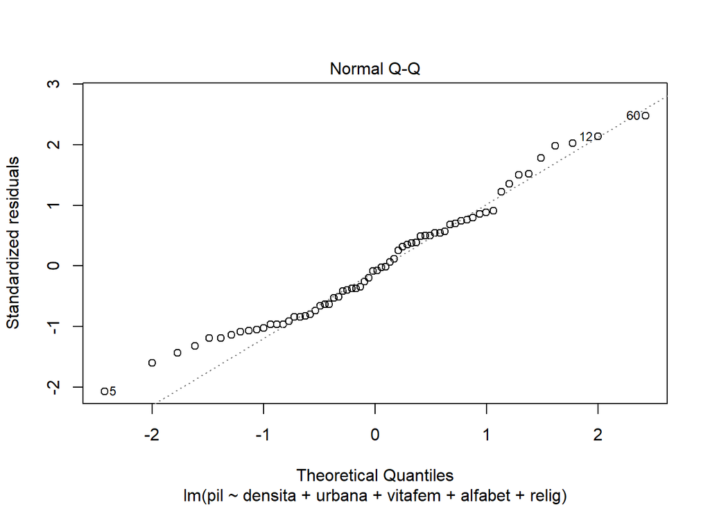

```r
par(mfrow=c(1,1))
plot(mod2_nazioni,which=2)
```

Per il test di shapiro i residui risultano essere non normali (p-value<0.05) Il QQ plot ci segnala la presenza di valori estrremi come la 5, la 12 e la 60 (e soprattutto nella parte inziale ci sono degli scostamenti rispetto alla normale)

Procedo ad eliminare gli outliers e le osservazioni influenti, come criteri usiamo un laverage > 2k/n e per gli studentized residuals usiamo valore assolute studentized residuals >2 (manteniamo quelli che non oltrepassano quindi queste soglie)

```r
nazioni2<-nazioni[hatvalues(mod2_nazioni)<=2*k/n & abs(rstudent(mod2_nazioni))<2,]
mod3_nazioni<-lm(pil~densita+urbana+vitafem+alfabet+relig, nazioni2)
```

confrontiamo le due regressioni con gli outliers e senza outliers

```r
summary(mod2_nazioni)
```

```
##
## Call:
## lm(formula = pil ~ densita + urbana + vitafem + alfabet + relig,
##     data = nazioni)
##
## Residuals:
##     Min      1Q  Median      3Q     Max
## -8357.1 -4109.6  -374.6  3196.2 12354.8
##
## Coefficients:
##               Estimate Std. Error t value Pr(>|t|)
## (Intercept) -22005.133   5205.608  -4.227 8.34e-05 ***
## densita          5.282      5.739   0.920  0.36115
## urbana          31.374     50.103   0.626  0.53360
## vitafem        330.796    149.148   2.218  0.03042 *
## alfabet         20.868     90.782   0.230  0.81899
## relig2       -2541.140   2102.705  -1.209  0.23167
## relig3        4836.980   1593.836   3.035  0.00358 **
## ---
## Signif. codes:  0 '***' 0.001 '**' 0.01 '*' 0.05 '.' 0.1 ' ' 1
##
## Residual standard error: 5126 on 59 degrees of freedom
## Multiple R-squared:  0.5125, Adjusted R-squared:  0.4629
## F-statistic: 10.34 on 6 and 59 DF,  p-value: 8.403e-08
```

```r
summary(mod3_nazioni)
```

```
##
## Call:
## lm(formula = pil ~ densita + urbana + vitafem + alfabet + relig,
##     data = nazioni2)
##
## Residuals:
##      Min       1Q   Median       3Q      Max
## -10367.0  -2959.9   -491.3   2948.4  10408.8
##
## Coefficients:
##               Estimate Std. Error t value Pr(>|t|)
## (Intercept) -19632.552   5572.814  -3.523 0.000899 ***
## densita         14.073      5.682   2.477 0.016547 *
## urbana          37.717     45.273   0.833 0.408600
## vitafem        287.755    146.204   1.968 0.054390 .
## alfabet          3.442     91.571   0.038 0.970158
## relig2       -1043.898   1804.111  -0.579 0.565342
## relig3        5995.940   1502.033   3.992 0.000207 ***
## ---
## Signif. codes:  0 '***' 0.001 '**' 0.01 '*' 0.05 '.' 0.1 ' ' 1
##
## Residual standard error: 4212 on 52 degrees of freedom
## Multiple R-squared:  0.5968, Adjusted R-squared:  0.5503
## F-statistic: 12.83 on 6 and 52 DF,  p-value: 7.82e-09
```

il modello senza outliers spiega meglio il pil rispetto a quello con gli outliers

## Studio dell’eteroschedasticità e risoluzione tramite il metodo FGLS

Settiamo la regressione sulla quale verrà poi studiata l’eteroschedasticità

```r
mod1_companies<-lm(mark_val~assets+sales+profits+cash+employ,companies)
summary(mod1_companies)
```

```
##
## Call:
## lm(formula = mark_val ~ assets + sales + profits + cash + employ,
##     data = companies)
##
## Residuals:
##      Min       1Q   Median       3Q      Max
## -1228.23  -222.80   -50.87   251.70  1180.29
##
## Coefficients:
##               Estimate Std. Error t value Pr(>|t|)
## (Intercept)  2.438e+02  1.030e+02   2.367   0.0213 *
## assets       2.066e-04  2.127e-02   0.010   0.9923
## sales       -1.802e-02  7.445e-02  -0.242   0.8096
## profits      8.828e-02  1.176e+00   0.075   0.9404
## cash         3.787e+00  8.620e-01   4.393 4.82e-05 ***
## employ       9.399e+00  4.875e+00   1.928   0.0587 .
## ---
## Signif. codes:  0 '***' 0.001 '**' 0.01 '*' 0.05 '.' 0.1 ' ' 1
##
## Residual standard error: 444.8 on 58 degrees of freedom
## Multiple R-squared:  0.7394, Adjusted R-squared:  0.7169
## F-statistic: 32.91 on 5 and 58 DF,  p-value: 9.393e-16
```

Andiamo ad indagare la presenza di eteroschedasticità inizialmente a livello grafico

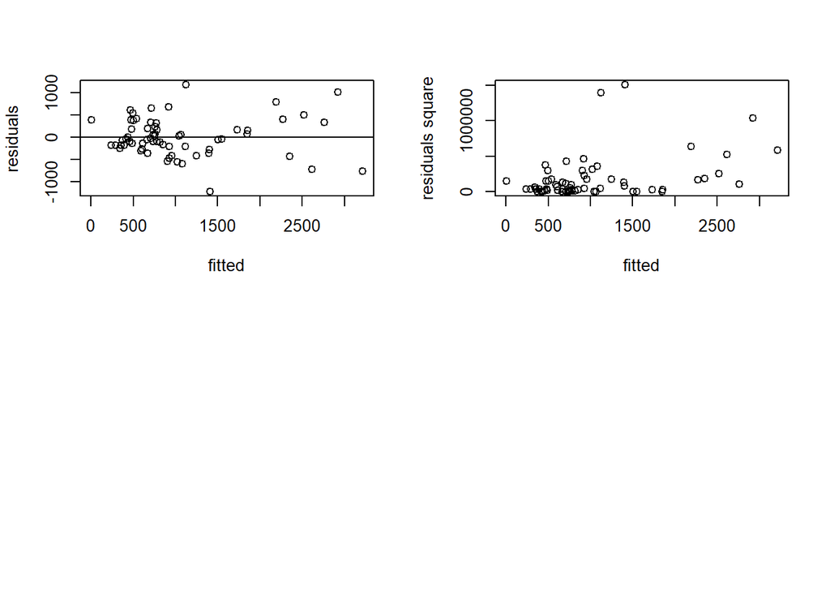

```r
par(mfrow=c(2,2)) # (2,2) per comodità nella rappresentazione
plot(mod1_companies$fitted,mod1_companies$residuals,xlab='fitted',ylab='residuals')
abline(h=0)
plot(mod1_companies$fitted,(mod1_companies$residuals)^2,xlab='fitted',ylab='residuals square')
```

La forma a ventaglio con la quale si distribuiscono i residui denota la presenza di eteroschedasticità Andiamo a veder il grafico dei residui rispetto ad ognuna delle variabili indipendenti

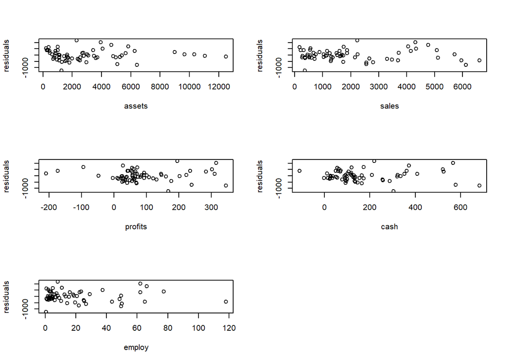

```r
par(mfrow=c(3,2))
var_indipendenti<-c('assets','sales','profits','cash','employ')
for (i in var_indipendenti){
  plot(companies[,i],mod1_companies$residuals,xlab=i,ylab='residuals')
}
```

Anche questo grafico segnala la presenza di eteroschedasticità

Andiamo ora ad indagare la presenza di eteroschedasticità attraverso alcuni appositi test

```r
white.test(mod1_companies)
```

```
##   Test.Statistic           P
## 1       9.406023 0.009067927
```

```r
white_lm(mod1_companies,interactions = T)
```

```
## # A tibble: 1 x 5
##   statistic p.value parameter method       alternative
##       <dbl>   <dbl>     <dbl> <chr>        <chr>
## 1      36.5  0.0135        20 White's Test greater
```

Entrambi segnalano la presenza di eteroschedasticità

Vediamo ora la risoluzione del problema di eteroschedasticità attraverso lo stimatore FGLS, la quale si divide in step: - Costruire un modello che ha i residui al quadrato come variabile dipendendente e come x le variabili indipendenti del modello di regressione eteroschedastico

```r
aux_companies<-lm(I(mod1_companies$residuals^2)~assets+sales+profits+cash+employ,companies)
summary(aux_companies)
```

```
##
## Call:
## lm(formula = I(mod1_companies$residuals^2) ~ assets + sales +
##     profits + cash + employ, data = companies)
##
## Residuals:
##     Min      1Q  Median      3Q     Max
## -358259 -146663  -33223   46966 1198288
##
## Coefficients:
##              Estimate Std. Error t value Pr(>|t|)
## (Intercept) 103852.98   64252.30   1.616   0.1114
## assets         -21.87      13.26  -1.649   0.1046
## sales          -10.26      46.44  -0.221   0.8259
## profits       -571.74     733.26  -0.780   0.4387
## cash          1267.04     537.70   2.356   0.0219 *
## employ        -243.62    3040.81  -0.080   0.9364
## ---
## Signif. codes:  0 '***' 0.001 '**' 0.01 '*' 0.05 '.' 0.1 ' ' 1
##
## Residual standard error: 277400 on 58 degrees of freedom
## Multiple R-squared:  0.209,  Adjusted R-squared:  0.1408
## F-statistic: 3.065 on 5 and 58 DF,  p-value: 0.016
```

- Andiamo a vedere le statistiche descrittive dei valori fitted del modello ausiliario

```r
summary(aux_companies$fitted.values)
```

```
##    Min. 1st Qu.  Median    Mean 3rd Qu.    Max.
##  -80634  114204  156567  179298  211041  556892
```

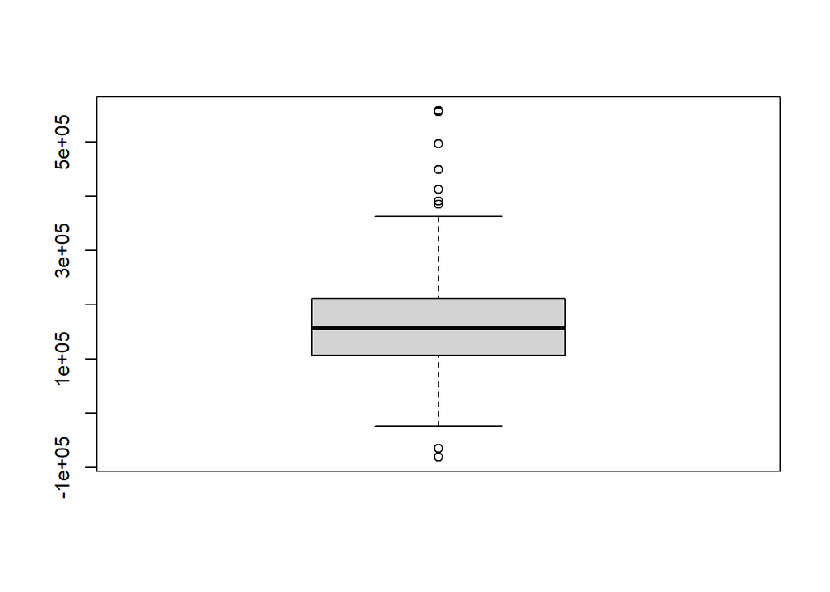

```r
boxplot(aux_companies$fitted.values)
```

Vediamo che aux predice valori negativi dei residui al quadrato (quindi non è un buon modello perchè i residui al quadrato sono di per se positivi) Rispecifichiamo quindi aux_companies applicando ai residui al quadrato la funzione logaritmo, così da avere risultati che sono sempre positivi

```r
aux_companies<-lm(I(log(mod1_companies$residuals^2))~assets+sales+profits+cash+employ,companies)
summary(aux_companies)
```

```
##
## Call:
## lm(formula = I(log(mod1_companies$residuals^2)) ~ assets + sales +
##     profits + cash + employ, data = companies)
##
## Residuals:
##     Min      1Q  Median      3Q     Max
## -6.6357 -0.6649  0.3790  1.2436  3.7077
##
## Coefficients:
##               Estimate Std. Error t value Pr(>|t|)
## (Intercept)  1.027e+01  4.563e-01  22.508   <2e-16 ***
## assets      -1.858e-04  9.420e-05  -1.973   0.0533 .
## sales        4.871e-05  3.298e-04   0.148   0.8831
## profits     -5.172e-03  5.208e-03  -0.993   0.3248
## cash         6.335e-03  3.819e-03   1.659   0.1025
## employ       1.338e-02  2.160e-02   0.620   0.5379
## ---
## Signif. codes:  0 '***' 0.001 '**' 0.01 '*' 0.05 '.' 0.1 ' ' 1
##
## Residual standard error: 1.97 on 58 degrees of freedom
## Multiple R-squared:  0.1926, Adjusted R-squared:  0.123
## F-statistic: 2.767 on 5 and 58 DF,  p-value: 0.02617
```

- Calcoliamo la standard deviation per ogni valore residuo, però prima devo ritrasformare dal logaritmo

```r
companies$varianza<-exp(aux_companies$fitted.values)
companies$sd<-sqrt(companies$varianza)
```

- Si costruisce il modello FGLS con le variabili trasformate e lo confrontiamo con quello precedente che aveva errori eteroschedastici

```r
fgls1_companies<-lm(I(mark_val/sd)~0+I(1/sd)+I(assets/sd)+I(profits/sd)+I(sales/sd)+I(cash/sd)+I(employ/sd),companies)
summary(fgls1_companies)
```

```
##
## Call:
## lm(formula = I(mark_val/sd) ~ 0 + I(1/sd) + I(assets/sd) + I(profits/sd) +
##     I(sales/sd) + I(cash/sd) + I(employ/sd), data = companies)
##
## Residuals:
##     Min      1Q  Median      3Q     Max
## -4.6940 -1.3034 -0.2434  1.1278  5.2908
##
## Coefficients:
##                 Estimate Std. Error t value Pr(>|t|)
## I(1/sd)       243.716439  77.769231   3.134  0.00271 **
## I(assets/sd)   -0.010719   0.009896  -1.083  0.28321
## I(profits/sd)   1.718887   1.339286   1.283  0.20444
## I(sales/sd)     0.051569   0.074081   0.696  0.48914
## I(cash/sd)      2.838162   1.067281   2.659  0.01011 *
## I(employ/sd)    4.518141   5.937544   0.761  0.44977
## ---
## Signif. codes:  0 '***' 0.001 '**' 0.01 '*' 0.05 '.' 0.1 ' ' 1
##
## Residual standard error: 1.834 on 58 degrees of freedom
## Multiple R-squared:  0.8922, Adjusted R-squared:  0.8811
## F-statistic: 80.04 on 6 and 58 DF,  p-value: < 2.2e-16
```

```r
summary(mod1_companies)
```

```
##
## Call:
## lm(formula = mark_val ~ assets + sales + profits + cash + employ,
##     data = companies)
##
## Residuals:
##      Min       1Q   Median       3Q      Max
## -1228.23  -222.80   -50.87   251.70  1180.29
##
## Coefficients:
##               Estimate Std. Error t value Pr(>|t|)
## (Intercept)  2.438e+02  1.030e+02   2.367   0.0213 *
## assets       2.066e-04  2.127e-02   0.010   0.9923
## sales       -1.802e-02  7.445e-02  -0.242   0.8096
## profits      8.828e-02  1.176e+00   0.075   0.9404
## cash         3.787e+00  8.620e-01   4.393 4.82e-05 ***
## employ       9.399e+00  4.875e+00   1.928   0.0587 .
## ---
## Signif. codes:  0 '***' 0.001 '**' 0.01 '*' 0.05 '.' 0.1 ' ' 1
##
## Residual standard error: 444.8 on 58 degrees of freedom
## Multiple R-squared:  0.7394, Adjusted R-squared:  0.7169
## F-statistic: 32.91 on 5 and 58 DF,  p-value: 9.393e-16
```

Vediamo che cash è rimasta significativa, anche se lo è molto meno, vediamo che il modello rimane significativo nel suo complesso e la bontà di afattamento del modello è cresciuta Andiamo a vedere se l’eteroschedasticità è stata risolta con il modello con stime FGLS

```r
white.test(fgls1_companies)
```

```
##   Test.Statistic         P
## 1      0.1750454 0.9161981
```

Vi è anche un metodo alternativo per costruire gli stimatori FGLS (anche se il prof consiglia comunque di utilizzare il primo metodo)

```r
fgls2_companies<-lm(mark_val~assets+sales+profits+cash+employ, weights=(1/companies$varianza),companies)
summary(fgls2_companies)
```

```
##
## Call:
## lm(formula = mark_val ~ assets + sales + profits + cash + employ,
##     data = companies, weights = (1/companies$varianza))
##
## Weighted Residuals:
##     Min      1Q  Median      3Q     Max
## -4.6940 -1.3034 -0.2434  1.1278  5.2908
##
## Coefficients:
##               Estimate Std. Error t value Pr(>|t|)
## (Intercept) 243.716439  77.769231   3.134  0.00271 **
## assets       -0.010719   0.009896  -1.083  0.28321
## sales         0.051569   0.074081   0.696  0.48914
## profits       1.718887   1.339286   1.283  0.20444
## cash          2.838162   1.067281   2.659  0.01011 *
## employ        4.518141   5.937544   0.761  0.44977
## ---
## Signif. codes:  0 '***' 0.001 '**' 0.01 '*' 0.05 '.' 0.1 ' ' 1
##
## Residual standard error: 1.834 on 58 degrees of freedom
## Multiple R-squared:  0.6829, Adjusted R-squared:  0.6556
## F-statistic: 24.98 on 5 and 58 DF,  p-value: 2.471e-13
```

Vediamo che i risultati sono identici rispetto a fgls1 (l’unica cosa che cambia sono gli square)

Andiamo a vedere ora un metodo alternativo per affrontare l’eteroschedasticità (guardare slide prof), HC3 viene utilizzato quando il dataset contiene meno di 250 osservazioni

```r
coeftest(mod1_companies, vcov=vcovHC(mod1_companies,type='HC3'))
```

```
##
## t test of coefficients:
##
##                Estimate  Std. Error t value Pr(>|t|)
## (Intercept)  2.4378e+02  1.0965e+02  2.2232  0.03011 *
## assets       2.0661e-04  1.5334e-02  0.0135  0.98930
## sales       -1.8019e-02  1.0774e-01 -0.1672  0.86776
## profits      8.8281e-02  1.9543e+00  0.0452  0.96413
## cash         3.7867e+00  1.4766e+00  2.5646  0.01294 *
## employ       9.3994e+00  7.8173e+00  1.2024  0.23410
## ---
## Signif. codes:  0 '***' 0.001 '**' 0.01 '*' 0.05 '.' 0.1 ' ' 1
```

```r
summary(mod1_companies)
```

```
##
## Call:
## lm(formula = mark_val ~ assets + sales + profits + cash + employ,
##     data = companies)
##
## Residuals:
##      Min       1Q   Median       3Q      Max
## -1228.23  -222.80   -50.87   251.70  1180.29
##
## Coefficients:
##               Estimate Std. Error t value Pr(>|t|)
## (Intercept)  2.438e+02  1.030e+02   2.367   0.0213 *
## assets       2.066e-04  2.127e-02   0.010   0.9923
## sales       -1.802e-02  7.445e-02  -0.242   0.8096
## profits      8.828e-02  1.176e+00   0.075   0.9404
## cash         3.787e+00  8.620e-01   4.393 4.82e-05 ***
## employ       9.399e+00  4.875e+00   1.928   0.0587 .
## ---
## Signif. codes:  0 '***' 0.001 '**' 0.01 '*' 0.05 '.' 0.1 ' ' 1
##
## Residual standard error: 444.8 on 58 degrees of freedom
## Multiple R-squared:  0.7394, Adjusted R-squared:  0.7169
## F-statistic: 32.91 on 5 and 58 DF,  p-value: 9.393e-16
```

Vediamo come i valori sono identici rispetto a quelli precedenti, ma gli std error sono più piccoli, quindi ci porteranno ad avere delle stime significative anche quando in realtà esse non lo sono

N.B: l’eteroschedasticità potrebbe anche essere dovuta ad una forma funzionale sbagliata, quindi un tentativo da fare potrebbe essere quello di provare varie forme funzionali, prima di ricorrere alle stime FGLS

## Studio e soluzione dell’autocorrelazione dei residui

Andiamo inizialemente a costruire la nostra regressione e guardare com’è il nostro modello

```r
mod1_hartangel<-lm(ftheft~partic+degrees+mtheft,hartangel)
summary(mod1_hartangel)
```

```
##
## Call:
## lm(formula = ftheft ~ partic + degrees + mtheft, data = hartangel)
##
## Residuals:
##     Min      1Q  Median      3Q     Max
## -9.8242 -3.2892  0.5658  2.5798  9.3956
##
## Coefficients:
##              Estimate Std. Error t value Pr(>|t|)
## (Intercept) -36.06091    8.11357  -4.445 0.000111 ***
## partic        0.14143    0.02849   4.965 2.57e-05 ***
## degrees       0.53861    0.05380  10.012 4.45e-11 ***
## mtheft        0.05282    0.02279   2.318 0.027467 *
## ---
## Signif. codes:  0 '***' 0.001 '**' 0.01 '*' 0.05 '.' 0.1 ' ' 1
##
## Residual standard error: 4.754 on 30 degrees of freedom
## Multiple R-squared:  0.9244, Adjusted R-squared:  0.9168
## F-statistic: 122.2 on 3 and 30 DF,  p-value: < 2.2e-16
```

Tutte le variabili sono significative, modello nel suo complesso è significativo, l’ R^2 è molto buono

Andiamo a vedere che gli errori sono omoschedastici

```r
white_lm(mod1_hartangel)
```

```
## # A tibble: 1 x 5
##   statistic p.value parameter method       alternative
##       <dbl>   <dbl>     <dbl> <chr>        <chr>
## 1      4.88   0.559         6 White's Test greater
```

Andiamo a vedere un diagramma dei residui nel tempo

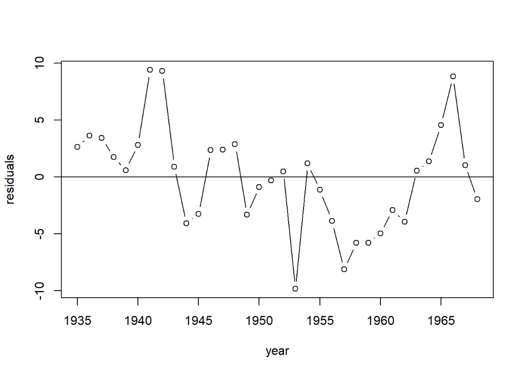

```r
plot(hartangel$year,mod1_hartangel$residuals,xlab='year',ylab='residuals',type='b')
abline(h=0)
```

Vediamo che vi sono situazioni che confermano un’autocorrelazione positiva di ordine 1 dei residui

Andiamo a verificare questa evidenza grafica con i correlogrammi

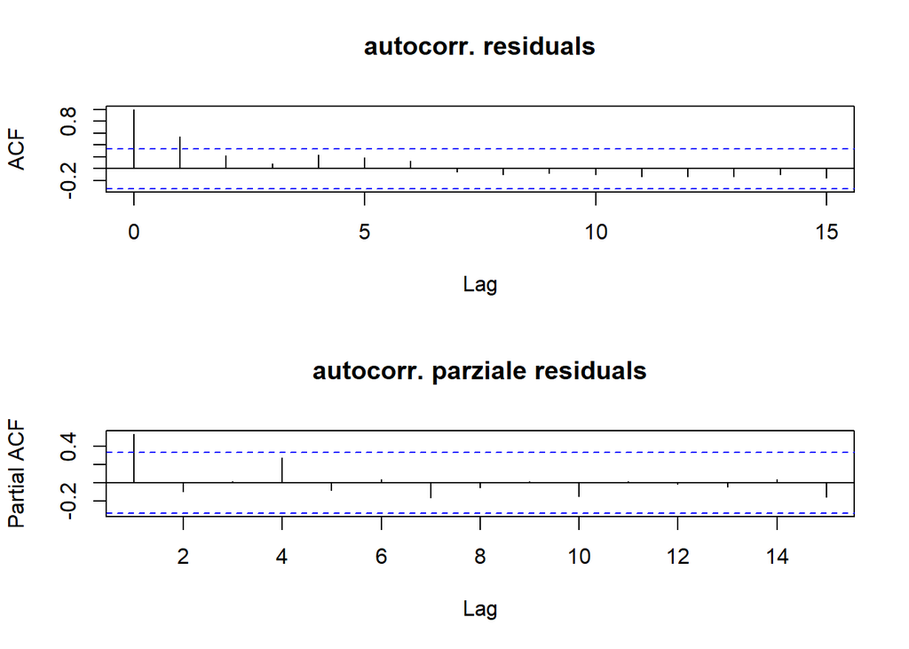

```r
par(mfrow=c(2,1))
acf(mod1_hartangel$residuals,main='autocorr. residuals')
pacf(mod1_hartangel$residuals,main='autocorr. parziale residuals')
```

Emerge l’autocorrelazione positiva di ordine uno sia per quanto riguarda le autocorrelazioni e le autocorrelazioni, mentre vediamo che anche l’autocorrelazione di quarto ordine vuole emergere, ma non supera il livello di significatività

Andiamo avedere con il test di darbinwatson se si ottengono ulteriori conferme riguardo la presenza di autocorrelazione (con max.lag=5 studiamo la presenza di autocorrelazione fino al quinto ordine)

```r
durbinWatsonTest(mod1_hartangel, max.lag=5)
```

```
##  lag Autocorrelation D-W Statistic p-value
##    1      0.53952640     0.9051118   0.002
##    2      0.22105334     1.5208872   0.114
##    3      0.08943159     1.6523470   0.320
##    4      0.22930798     1.3375369   0.130
##    5      0.18871355     1.4154863   0.288
##  Alternative hypothesis: rho[lag] != 0
```

Vediamo che con il test di Durbin Watson risulta significativa l’autocorrelazione di primo ordine

3.Studio dell’ autocorrelazione Cerchiamo di risolvere il problema di autocorrelazione con la procedura di cochrane-orcutt, la quale si divide in diversi passi, questa procedura può essere utilizzata anche per ordini superiori :

- Ottenere i residui di mod1_hartangel, per fare ciò andiamo a creare i residui ritardati attraverso la funzione datacombine, andiamo in fine ad andare a visualizzare i dati per verificare di avere realmente creato i residui ritardati

```r
hartangel$u_hat<-mod1_hartangel$residuals
hartangel<-slide(data=hartangel,Var='u_hat',TimeVar='year',NewVar='u_hat_lag')
```

```
##
## Lagging u_hat by 1 time units.
```

```r
View(hartangel)
```

- regressione di uhat su u_hat_lag (ovvero regressione dei residui sui residui di lag1), in quanto vogliamo andare a ricercare il coefficente di autocorrelazione p

```r
aux_hartangel<-lm(u_hat~u_hat_lag,hartangel)
summary(aux_hartangel)
```

```
##
## Call:
## lm(formula = u_hat ~ u_hat_lag, data = hartangel)
##
## Residuals:
##     Min      1Q  Median      3Q     Max
## -9.9764 -2.3988  0.0085  2.3227  7.9746
##
## Coefficients:
##             Estimate Std. Error t value Pr(>|t|)
## (Intercept)  -0.1119     0.6795  -0.165  0.87024
## u_hat_lag     0.5429     0.1503   3.612  0.00106 **
## ---
## Signif. codes:  0 '***' 0.001 '**' 0.01 '*' 0.05 '.' 0.1 ' ' 1
##
## Residual standard error: 3.903 on 31 degrees of freedom
##   (1 observation deleted due to missingness)
## Multiple R-squared:  0.2961, Adjusted R-squared:  0.2734
## F-statistic: 13.04 on 1 and 31 DF,  p-value: 0.001061
```

Stimiamo il coefficente di autocorrelazione 0.5429

- Memorizziamo il coefficiente di autocorrelazione (che corrisponde al secondo elemento di aux_hartangel)

```r
rho_hartangel<-aux_hartangel$coefficients[2]
```

- Tramite la funzione slide andiamo a creare ftheft lag e anche tutte le altre variabili lag (ritardate)

```r
hartangel<-slide(data=hartangel,Var='ftheft',TimeVar='year',NewVar='ftheft_lag')
```

```
##
## Lagging ftheft by 1 time units.
```

```r
hartangel<-slide(data=hartangel,Var='mtheft',TimeVar='year',NewVar='mtheft_lag')
```

```
##
## Lagging mtheft by 1 time units.
```

```r
hartangel<-slide(data=hartangel,Var='partic',TimeVar='year',NewVar='partic_lag')
```

```
##
## Lagging partic by 1 time units.
```

```r
hartangel<-slide(data=hartangel,Var='degrees',TimeVar='year',NewVar='degrees_lag')
```

```
##
## Lagging degrees by 1 time units.
```

```r
View(hartangel)
```

- Andiamo a calcolare le variabili trasformate tramite il coefficente di autocorrelazione

```r
hartangel$ftheft_t<-hartangel$ftheft-rho_hartangel*hartangel$ftheft_lag
hartangel$mtheft_t<-hartangel$mtheft-rho_hartangel*hartangel$mtheft_lag
hartangel$partic_t<-hartangel$partic-rho_hartangel*hartangel$partic_lag
hartangel$degrees_t<-hartangel$degrees-rho_hartangel*hartangel$degrees_lag
hartangel$interc_t<-1-rho_hartangel
```

- Stimiamo il modello delle variabili trasformate (metto lo zero perchè devo togliere la costante del modello e al suo posto sarà inserito 1-rho) e lo confrontiamo con quello del modello con errori correlati

```r
mod2_hartangel<-lm(ftheft_t~0+interc_t+partic_t+ degrees_t+mtheft_t,hartangel)
summary(mod2_hartangel)
```

```
##
## Call:
## lm(formula = ftheft_t ~ 0 + interc_t + partic_t + degrees_t +
##     mtheft_t, data = hartangel)
##
## Residuals:
##      Min       1Q   Median       3Q      Max
## -10.6504  -2.0545  -0.1914   2.0164   8.0233
##
## Coefficients:
##            Estimate Std. Error t value Pr(>|t|)
## interc_t  -26.82350   10.27163  -2.611  0.01413 *
## partic_t    0.11814    0.03537   3.340  0.00231 **
## degrees_t   0.51676    0.06954   7.431 3.45e-08 ***
## mtheft_t    0.04257    0.03074   1.385  0.17672
## ---
## Signif. codes:  0 '***' 0.001 '**' 0.01 '*' 0.05 '.' 0.1 ' ' 1
##
## Residual standard error: 3.944 on 29 degrees of freedom
##   (1 observation deleted due to missingness)
## Multiple R-squared:  0.9517, Adjusted R-squared:  0.945
## F-statistic: 142.8 on 4 and 29 DF,  p-value: < 2.2e-16
```

```r
summary(mod1_hartangel)
```

```
##
## Call:
## lm(formula = ftheft ~ partic + degrees + mtheft, data = hartangel)
##
## Residuals:
##     Min      1Q  Median      3Q     Max
## -9.8242 -3.2892  0.5658  2.5798  9.3956
##
## Coefficients:
##              Estimate Std. Error t value Pr(>|t|)
## (Intercept) -36.06091    8.11357  -4.445 0.000111 ***
## partic        0.14143    0.02849   4.965 2.57e-05 ***
## degrees       0.53861    0.05380  10.012 4.45e-11 ***
## mtheft        0.05282    0.02279   2.318 0.027467 *
## ---
## Signif. codes:  0 '***' 0.001 '**' 0.01 '*' 0.05 '.' 0.1 ' ' 1
##
## Residual standard error: 4.754 on 30 degrees of freedom
## Multiple R-squared:  0.9244, Adjusted R-squared:  0.9168
## F-statistic: 122.2 on 3 and 30 DF,  p-value: < 2.2e-16
```

Vediamo che dopo aver corretto per l’autocorrelazione mtheft non è più significativo e il modello si adatta molto bene ai dati

Andiamo allora a vedere dal test di dw la presenza di autocorrelazione dei residui o meno a 5 lag

```r
durbinWatsonTest(mod2_hartangel, max.lag=5)
```

```
##  lag Autocorrelation D-W Statistic p-value
##    1      0.09711383      1.795933   0.278
##    2      0.04064272      1.895891   0.718
##    3     -0.06849700      1.971350   0.848
##    4      0.21131125      1.358931   0.196
##    5      0.04234945      1.677867   0.854
##  Alternative hypothesis: rho[lag] != 0
```

Vediamo che il test conferma che abbiamo eliminato l’autocorrelazione dei residui

Controlliamo anche per via grafica di aver eliminato l’autocorrelazione dei residui

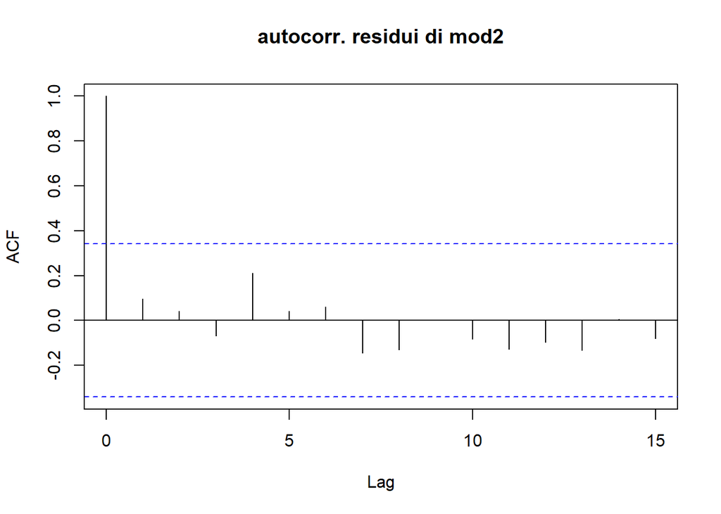

```r
acf(mod2_hartangel$residuals,main='autocorr. residui di mod2')
```

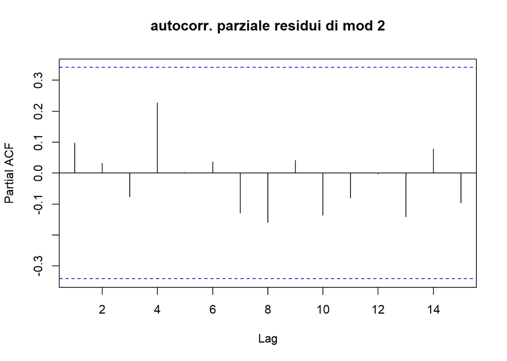

```r
pacf(mod2_hartangel$residuals,main='autocorr. parziale residui di mod 2')
```

vediamo anche come i correlogrammmi indicano che non vi sia più autocorrelazione

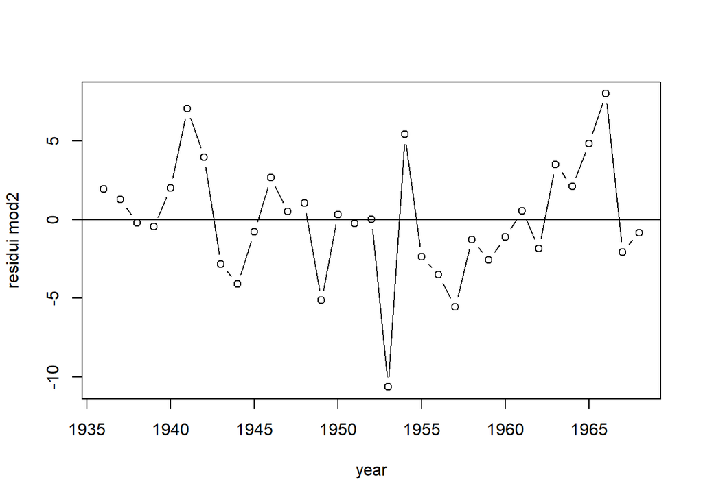

```r
plot(hartangel$year[-1], mod2_hartangel$residuals,xlab='year',ylab='residui mod2',type='b')
abline(h=0)
```

Vediamo un secondo approccio, ovvero quello basato sul modello autoregressivo, order è un vettore con numero di AR, numero di differenziazioni, Numero di Ma. ML indica la massima verosomiglianza. se cambio nel vettore order il numero 1 con per esempio 4 calcolo le stime per autocorrelazioni di quarto ordine

```r
library('lmtest')
mod3_hartangel<-arima(hartangel$ftheft, order=c(1,0,0),xreg=hartangel[,c('partic','degrees','mtheft')],method='ML')
coeftest(mod3_hartangel) #abbiamo la significativit? di partic e degrees ma non pi? di mtheft
```

```
##
## z test of coefficients:
##
##            Estimate Std. Error z value Pr(>|z|)
## ar1        0.939946   0.080392 11.6920  < 2e-16 ***
## intercept -0.186927  16.741448 -0.0112  0.99109
## partic     0.079676   0.033487  2.3793  0.01735 *
## degrees    0.296180   0.129031  2.2954  0.02171 *
## mtheft     0.016240   0.031186  0.5207  0.60255
## ---
## Signif. codes:  0 '***' 0.001 '**' 0.01 '*' 0.05 '.' 0.1 ' ' 1
```

Se cambio nel vettore order il numero 1 con per esempio 4 calcolo le stime fino per le autocorrelazioni di quarto ordine

```r
mod4_hartangel<-arima(hartangel$ftheft, order=c(4,0,0),xreg=hartangel[,c('partic','degrees','mtheft')],method='ML')
coeftest(mod4_hartangel)
```

```
##
## z test of coefficients:
##
##             Estimate Std. Error z value  Pr(>|z|)
## ar1         0.654186   0.199435  3.2802 0.0010374 **
## ar2        -0.072927   0.207931 -0.3507 0.7257923
## ar3        -0.194223   0.239285 -0.8117 0.4169761
## ar4         0.273245   0.188652  1.4484 0.1475031
## intercept -34.326796  14.769883 -2.3241 0.0201197 *
## partic      0.134097   0.039449  3.3992 0.0006758 ***
## degrees     0.490159   0.081456  6.0175 1.772e-09 ***
## mtheft      0.060875   0.032835  1.8539 0.0637463 .
## ---
## Signif. codes:  0 '***' 0.001 '**' 0.01 '*' 0.05 '.' 0.1 ' ' 1
```

Vedo che ar4 però non è significativa, tengo buona quindi l’ipotesi di autocorrelazione di primo ordine

## Test F per restrizioni multiple sulle variabili singolarmente non significative

Andiamo ora a testare se vi siano delle restrizioni multiple, ovvero testare che siano uguali a zero i coefficienti delle variabili che non risultavano significative, ovvero urbana, alfabet e relig2 (nel dataset delle nazioni)

```r
linearHypothesis(mod3_nazioni,c('urbana=0','relig2=0', 'alfabet=0'))
```

```
## Linear hypothesis test
##
## Hypothesis:
## urbana = 0
## relig2 = 0
## alfabet = 0
##
## Model 1: restricted model
## Model 2: pil ~ densita + urbana + vitafem + alfabet + relig
##
##   Res.Df       RSS Df Sum of Sq      F Pr(>F)
## 1     55 943109645
## 2     52 922353689  3  20755956 0.3901 0.7606
```

vediamo che questo test ci porta a non rigettare l’ipotesi nulla che i tre coefficienti siano uguali a zero

```r
mod4_nazioni<-lm(pil~densita+vitafem, nazioni2)
summary(mod4_nazioni)
```

```
##
## Call:
## lm(formula = pil ~ densita + vitafem, data = nazioni2)
##
## Residuals:
##    Min     1Q Median     3Q    Max
##  -7403  -3964  -1016   3699   8994
##
## Coefficients:
##               Estimate Std. Error t value Pr(>|t|)
## (Intercept) -26797.536   5368.682  -4.991 6.18e-06 ***
## densita         15.171      6.549   2.316   0.0242 *
## vitafem        436.936     71.089   6.146 8.78e-08 ***
## ---
## Signif. codes:  0 '***' 0.001 '**' 0.01 '*' 0.05 '.' 0.1 ' ' 1
##
## Residual standard error: 4889 on 56 degrees of freedom
## Multiple R-squared:  0.4148, Adjusted R-squared:  0.3939
## F-statistic: 19.85 on 2 and 56 DF,  p-value: 3.046e-07
```